# MATES_analysis

## Question 12

What is the importance of reporting the primary model (or first model) used to conduct the meta-analysis to the quality of reporting?

Referring to MATES item 5:

Do the authors report the primary model (or first model) used, either as word or statistical notation within the manuscript or supplementary material?

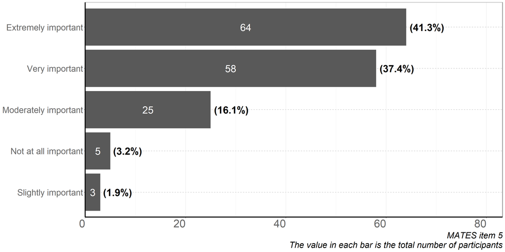

```r
# Separate rows and count total
total_model_importance_count <- dat %>%
  filter(!is.na(Q12)) %>%
  count(Q12) %>%
  arrange(desc(n))

# Calculate count as a percentage
total_model_importance_percentage <-  total_model_importance_count %>%
  mutate(proportion = n/sum(total_model_importance_count$n),
         percentage = proportion*100)

# Plot for survey question 12
fig_Q12 <-  total_model_importance_count %>%
  ggplot(aes(x = n, y =reorder(Q12, n)), hjust = 0.5) +
  geom_bar(stat = "identity") +
  geom_text(aes(label = n, x = n/2 , y = reorder(Q12,n)), hjust = 0.5, size = 8, color = "white") +
 geom_text(data = total_model_importance_percentage, aes(label = paste0("(", round(percentage, 1), "%)"), x = n),
            hjust = -0.1, size = 8, color = "black", fontface = "bold") +
  scale_fill_identity(guide = "none") +
  scale_x_continuous(expand = c(0,0), limits = c(0, max(total_model_importance_count$n*1.3))) +
  MATES_theme() +
  labs(caption = "MATES item 5\nThe value in each bar is the total number of participants")

fig_Q12
```

```r
# ggsave(here("survey_results", "fig_Q12.jpg"),  width = 16, height = 8, units = "cm", scale = 2, dpi = 120 )
```

## Question 13

Comments on MATES item 5 (e.g., potential improvements or a justification of response)

```r
# Filter for question 13
df_Q13 <- dat %>%
  filter(!is.na(Q13)) %>%
  select(c(Q12,Q13))

# Table for question 13
 kable(df_Q13, "html") %>%
    kable_styling("bordered", position = "left") %>%
    scroll_box(width = "150%", height = "400px")
```

| Q12 | Q13 |
| --- | --- |
| Moderately important | I do think it is important, although I the vocabulary of model names vary across disciplines. I think reporting the packages used and describing the response/fixed/random variables used is more inform… |
| Extremely important | These information if of vital importance. |
| Extremely important | I think the statistical notation can be confusing, we all know (I think) what a fixed/random/mixed model is. I would advise just saying it and putting a reference for those who are interested. |
| Very important | Every model that provides results in the manuscript should be reported. |
| Extremely important | Reporting the primary model (or first model) used to conduct the meta-analysis is important because it allows other researchers to understand the specific assumptions that were made about the data and… |
| Extremely important | The most important piece of information |
| Very important | A generic flow chart with detailed explanation is important |
| Extremely important | For all of these the importance is in allowing reproducibility |
| Very important | Yes, often text description are not very clear. Write clearly the equation is a good method to clearly define the model, the variables, with variables are considered as random effect,…. |
| Extremely important | To enable the reader to determine whether an appropriate model has been sued, and how random effects etc. have been dealt with. |
| Moderately important | maybe, it can be in supplementary files |
| NA | unsure what is meant by “primary model (or first model)” |
| Extremely important | I think this notation should be “general” and avoid software specific notation. E.g., not everyone is facile with the idiosyncrasies of various packages in R. Of course, the code will provide the info… |
| Slightly important | If the flow of research is explained, data could be requested to the authors for further clarification on the first models. The final model with the appropiate sensitivity testing should be enouth to … |
| Moderately important | Depends on the complexity of the model. For a mixed effect model, I think its ok to just list the fixed and random terms in text. |
| Extremely important | Yes, as said above, we need the code and the model. |
| NA | I’m not sure what a primary model is, which may indicate something me more than the question. |
| Not at all important | should be sufficient to say what studies go in the meta-analysis and the structure of the variables (exposure/response). |
| Extremely important | I think reporting the model and code used should be mandatory in all journals to ensure repeatability of the review plus make scrutinising results easier. |
| Not at all important | I don’t understand what is meant with primary model in this question, so I can’t really answer this question |
| NA | It’s not clear to me what is meant by ‘first model’ but maybe I’m missing something. I wonder if it might be beneficial to split this item up: as verbal description and as statistical notation. I find… |
| Very important | This item is slightly unclear. Is by “reporting the model”, you mean reporting the model structure and characteristics? i.e., the response variables, covariates, and random effects? It is of course im… |
| Moderately important | I don’t use statistical notation myself, so I don’t really care about their presentation. The code is much more useful. |
| Extremely important | Extremely important due to range of models with different goals available. It is however not unusual for reviewers to insist on removing elements usually to the supplementary materials section of cont… |
| Extremely important | Detailed reporting of the first model used in a meta-analysis is key to the quality of scientific reporting as it impacts a clear understanding of how the analyzes were performed. This is essential so… |
| Extremely important | I would avoid statistical notation unless it adds something. The main models are fairly well described. A reference to the model might be more useful. |
| Extremely important | This is fundamental to assess the model and the alternative, also for sensitivity analysis. |
| Moderately important | I’m actually not entirely sure what you mean by “primary model used” – used to do what? Are you talking about the probability distributions? Might want to make question more specific. |
| Moderately important | The importance of this item likely depends on the question being asked |
| Very important | It is important to report the type of model run and the estimator used. |
| Extremely important | Quality |
| Extremely important | Authors should report the primary model (or first model) for transparency, and also to train readers and new researchers in the field. |
| Moderately important | it is not relevant to all meta analyses. |
| Extremely important | This is crucial. Different models will give different results. |
| Extremely important | inclusion/exclusion criteria should be described |
| Extremely important | If what you call the ‘first model’ means the basic structure of the analysis, this is possibly the most important step. Qualified data stratification and data sorting by co-variable is the alpha and o… |
| Very important | I am not sure what is referred to as primary (or first) model – but the rationale of how and why the model is built as it is, should be clearly explained and reasoned (this is why I responded “very im… |
| Very important | This can enhance methodological transparency and allow for comparisons with alternative models (i.e. sensitivity analyses) |
| Moderately important | Same remark as before applies here. |

```r
# write_csv(df_Q13, file = here("survey_results", "df_Q13.csv"))
```

## Question 14

What is the importance of reporting a justification of the primary model (or first model) used to conduct the meta-analysis to the quality of reporting?

Referring to MATES item 6:

Do the authors report a justification for the primary model (or first model) used to conduct the analysis within the manuscript or supplementary material?

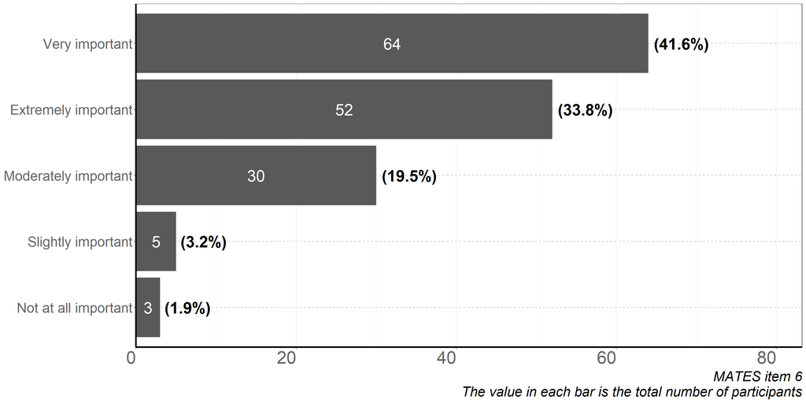

```r
# Separate rows and count total
total_justification_importance_count <- dat %>%
  filter(!is.na(Q14)) %>%
  count(Q14) %>%
  arrange(desc(n))

# Calculate count as a percentage
total_justification_importance_percentage <-  total_justification_importance_count %>%
  mutate(proportion = n/sum(total_justification_importance_count$n),
         percentage = proportion*100)

# Plot for survey question 14
fig_Q14 <-  total_justification_importance_count %>%
  ggplot(aes(x = n, y = reorder(Q14, n)), hjust = 0.5) +
  geom_bar(stat = "identity") +
  geom_text(aes(label = n, x = n/2 , y = reorder(Q14, n)), hjust = 0.5, size = 8, color = "white") +
 geom_text(data = total_justification_importance_percentage, aes(label = paste0("(", round(percentage, 1), "%)"), x = n),
            hjust = -0.1, size = 8, color = "black", fontface = "bold") +
  scale_fill_identity(guide = "none") +
  scale_x_continuous(expand = c(0,0), limits = c(0, max(total_justification_importance_count$n*1.3))) +
  MATES_theme() +
  labs(caption = "MATES item 6\nThe value in each bar is the total number of participants")

fig_Q14
```

```r
# ggsave(here("survey_results", "fig_Q14.jpg"),  width = 16, height = 8, units = "cm", scale = 2, dpi = 120 )
```

## Question 15

Comments on MATES item 6 (e.g., potential improvements or a justification of response)

```r
# Filter for question 15
df_Q15 <- dat %>%
  filter(!is.na(Q15)) %>%
  select(c(Q14,Q15))

# Table for question 15
 kable(df_Q15, "html") %>%
    kable_styling("bordered", position = "left") %>%
    scroll_box(width = "150%", height = "400px")
```

| Q14 | Q15 |
| --- | --- |
| Extremely important | More requirement should be put on the information disclosure. |
| Very important | Just a sentence will do. It gives the reader an idea if they know what they are doing (for example using a fixed-effects model because there ‘was no heterogeneity’ is not a great sign) |
| Moderately important | There is not much choice in a meta-analysis, so the few constrains and assumptions should be reported, but there is not a big variety so not much justification is needed |
| Very important | Reporting a justification for the primary model (or first model) used to conduct the meta-analysis is important because it helps other researchers to understand why the chosen model was the most appro… |
| Slightly important | I guess the most trivial justification would be that the selected type of model best fits the data. Not sure if such justification needs to be mentioned in the manuscript. |
| Very important | Good to provide rationale of the selection |
| Very important | yes, for me authors should justify why the do not used random effect model, and proper weighting,… (if it is the case). |
| Very important | needed to see that hte authors have considered other analysis as well. |
| NA | same comment as previous |
| Very important | The challenge here is what qualifies as “justification”? Is it a citation of another paper or book? Or something more substantive? |
| Very important | I think any model used should be mentioned, with justification of why a change is needed. I don’t think too much detail is needed though on the first model. |
| Moderately important | Same comment as the question before |
| Moderately important | Model may be equal to “hypothesis”? |
| Very important | ’-Some papers may not have a primary model but go straight to meta-regression. From my point of view, this would be the criterion to select NA in this question (and it would be a matter for procedural… |
| Extremely important | Definitely needed as this will give some clues about the extent authors understand the model and its assumptions. |
| Not at all important | Similar to Q12, I don’t understand this question/what primary model means, so I assume it is not important |
| Moderately important | Justification is clearly important, I’m just not sure if there should always be a strict statement of it. Also, how much of the model has to be justified, exactly? There’s a lot when you think about i… |
| Moderately important | I am not sure I fully understand this item. Are you asking for a justification as to why this particular type of model or package was used? Or a justification for why some covariates and random effect… |
| Very important | Could perhaps use some specificity. E.g., why did the authors use fixed/random effects/REML, etc). How did they harmonise across studies, e.g., where one paper used a continuous exposure measure while… |
| Extremely important | Justifying the primary model in a meta-analysis is essential for the quality of the scientific report. This practice ensures transparency in model selection, facilitates the evaluation of its suitabil… |
| Extremely important | Just needs a line or two. |
| Very important | Relevant to provide information of any difference due to model used. |
| Moderately important | See response to previous question |
| Very important | This can be really useful as a reviewer if things don’t seem to match up (e.g. question, analysis, results) then it can help to work out where the issue lies (e.g. poorly articulated question, or misu… |
| Extremely important | to provide clear and reliable conclusions, to convey vast amounts of information |
| Extremely important | Readers should understand the reasoning behind including the variables introduced in the models. |
| Moderately important | This might not be crucial for the quality of the study itself because if the type of model was already specified, reproducing the analysis should yield the same results. I think this would be rather i… |
| Extremely important | Most often, the justification of how (and why) data were structured in the way this was done is insufficient. |
| Very important | If the first model was discarded, it is crucial to know the first approach that the authors used, in order to evaluate the improvements and changes on the final model. |
| Extremely important | I think this answer reflects actually how I understood the previous question |
| Very important | This is for documentation for future reference and for communication of specific choices. |

```r
# write_csv(df_Q15, file = here("survey_results", "df_Q15.csv"))
```

## Question 16

What is the importance of reporting a weighting scheme for effect size estimates in a meta-analysis to the quality of reporting?

Referring to MATES item 7:

Do the authors report a weighting scheme for effect size estimates within the manuscript or supplementary material?

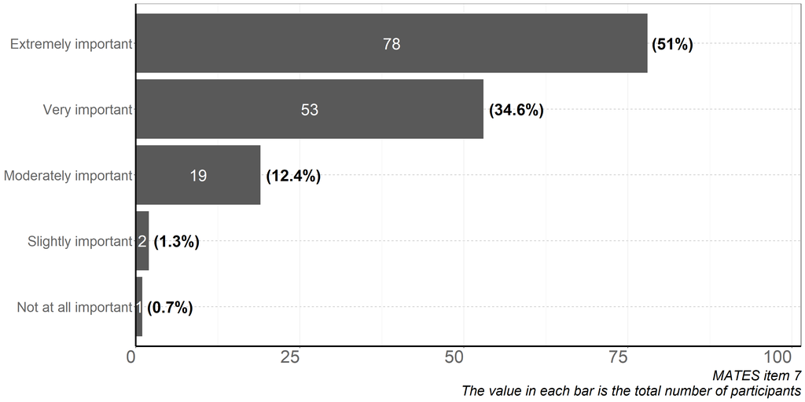

```r
# Separate rows and count total
total_weighting_scheme_importance_count <- dat %>%
  filter(!is.na(Q16)) %>%
  count(Q16) %>%
  arrange(desc(n))

# Calculate count as a percentage
total_weighting_scheme_importance_percentage <-  total_weighting_scheme_importance_count %>%
  mutate(proportion = n/sum(total_weighting_scheme_importance_count$n),
         percentage = proportion*100)

# Plot for survey question 16
fig_Q16 <-  total_weighting_scheme_importance_count %>%
  ggplot(aes(x = n, y = reorder(Q16, n)), hjust = 0.5) +
  geom_bar(stat = "identity") +
  geom_text(aes(label = n, x = n/2 , y = reorder(Q16, n)), hjust = 0.5, size = 8, color = "white") +
 geom_text(data = total_weighting_scheme_importance_percentage, aes(label = paste0("(", round(percentage, 1), "%)"), x = n),
            hjust = -0.1, size = 8, color = "black", fontface = "bold") +
  scale_fill_identity(guide = "none") +
  scale_x_continuous(expand = c(0,0), limits = c(0, max(total_weighting_scheme_importance_count$n*1.3))) +
  MATES_theme() +
  labs(caption = "MATES item 7\nThe value in each bar is the total number of participants")

fig_Q16
```

```r
# ggsave(here("survey_results", "fig_Q16.jpg"),  width = 16, height = 8, units = "cm", scale = 2, dpi = 120 )
```

## Question 17

Comments on MATES item 7 (e.g., potential improvements or a justification of response)

```r
# Filter for question 17
df_Q17 <- dat %>%
  filter(!is.na(Q17)) %>%
  select(c(Q16,Q17))

# Table for question 17
 kable(df_Q17, "html") %>%
    kable_styling("bordered", position = "left") %>%
    scroll_box(width = "250%", height = "800px")
```

| Q16 | Q17 |
| --- | --- |
| Extremely important | Essential information. |
| Moderately important | It is really only important if they are dong something different. |
| Extremely important | If there is one sure |
| Extremely important | Reporting a weighting scheme for effect size estimates in a meta-analysis is important because it allows other researchers to understand how the different studies in the meta-analysis were weighted re… |
| Very important | If there was any weighing, it must also be reported together with the model description. |
| Very important | Understand more about the assumptions and limitations of the study |
| Very important | The hypotheses for unweighted meta-analyses are very strong. Numerous publications demonstrate the potential biais using this method, so yes, weighting are of primary importance. + Now some tools/meth… |
| Extremely important | Very important, as this can obviously completely change the results |
| Extremely important | this may not be present in many papers |
| Very important | Full understanding of the weighting scheme for effect size is critical for understanding the context of the review and assessing its quality |
| NA | Perhaps be more specific about what is meant by a weighting scheme |
| Extremely important | This is very basic information. |
| Extremely important | Results will vary depending on this, so it must be reported. |
| Extremely important | To clear potential Bias |
| Very important | This can swing results so is important to know. |
| Extremely important | The more use of weighting for effect size estimates in a meta-analysis the more rubust is the analysis and interpretation of data |
| Extremely important | I dont really understand the question. If the authors feel a weighting scheme is appropriate, it should be justified. But I think there are circumstances when weighting isnt appropriate, but this shou… |
| Extremely important | One certainly should include the weighting scheme, though the wording of this suggests that if an unweighted scheme is chosen (e.g. due to limitations in the reporting of the original studies) this is… |
| Extremely important | There should be an NA option, which is when no weighting scheme was implemented |
| Extremely important | not all meta-analyses are centred around effect sizes, but in any case, weighting is important |
| Very important | Perhaps include “…weighting scheme for effect size estimates *or otherwise account for such weights within the analysis*…” My thinking is that it might not always be necessary to weight the effect siz… |
| Extremely important | Some authors, and I would agree with this definition, would only consider a study a “meta-analysis” if effect sizes are weighted; so it is indeed important. However, I feel like the phrasing of this i… |
| Extremely important | Reporting the weighting scheme in a meta-analysis is relevant for the quality of the scientific report. This ensures accurate estimations of the effect size, taking into account the variability and sa… |
| Extremely important | I think this one is pretty basic, and journal editors generally won’t allow it to be published if it’s not there. |
| Moderately important | In reality this is unusually going to be the default inverse variance. I would like to see authors noting differences between weighting in fixed/common-effects models and random effects. |
| Extremely important | At least of main analysis, they should be reported in order to adequate compare them |
| Extremely important | Potential for bias and important for repeatability |
| Very important | Meta-analyses can provide more accurate effect size estimates for power analyses, and correctly reporting effect size estimates can facilitate . |
| Extremely important | Readers should understand the reasoning behind the weighting scheme applied to the models. |
| Moderately important | it is not relevant to all meta analyses. |
| Extremely important | If this is not reported and one were to repeat the analysis, the results would be different. |
| Extremely important | If weighing is supposed to indicate the weight of certain frame conditions he data are nested in, this is super important. To give you an example: An analysis for the influence of CO2 on plant growth … |
| Moderately important | This criteria seems more study-specific than the previous metrics |
| Very important | In addition to reporting the weighting, the authors must declare the criteria with which they established the weights of each response to make them comparable between the different studies analyzed. |
| Extremely important | For understanding the sources of heterogeneity and for future reference. |

```r
# write_csv(df_Q17, file = here("survey_results", "df_Q17.csv"))
```

## Question 18

What is the importance of reporting a consideration of non-independence of effect size estimates in a meta-analysis to the quality of reporting?

Referring to MATES item 8:

Do the authors report whether there is non-independence of effect size estimates within the manuscript or supplementary material?

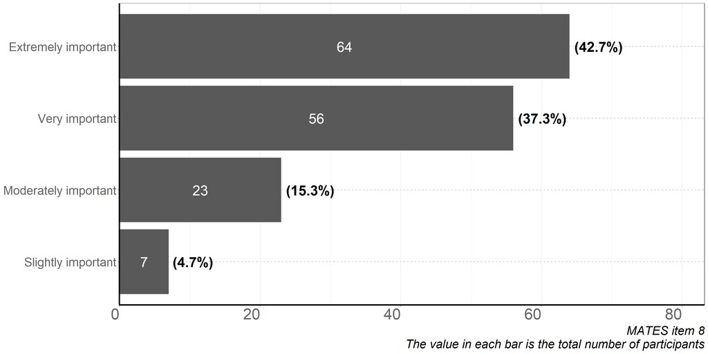

```r
# Separate rows and count total
total_non_independence_importance_count <- dat %>%
  filter(!is.na(Q18)) %>%
  count(Q18) %>%
  arrange(desc(n))

# Calculate count as a percentage
total_non_independence_importance_percentage <-  total_non_independence_importance_count %>%
  mutate(proportion = n/sum(total_non_independence_importance_count$n),
         percentage = proportion*100)

# Plot for survey question 18
fig_Q18 <-  total_non_independence_importance_count %>%
  ggplot(aes(x = n, y = reorder(Q18, n)), hjust = 0.5) +
  geom_bar(stat = "identity") +
  geom_text(aes(label = n, x = n/2 , y = reorder(Q18, n)), hjust = 0.5, size = 8, color = "white") +
 geom_text(data = total_non_independence_importance_percentage, aes(label = paste0("(", round(percentage, 1), "%)"), x = n),
            hjust = -0.1, size = 8, color = "black", fontface = "bold") +
  scale_fill_identity(guide = "none") +
  scale_x_continuous(expand = c(0,0), limits = c(0, max(total_non_independence_importance_count$n*1.3))) +
  MATES_theme() +
  labs(caption = "MATES item 8\nThe value in each bar is the total number of participants")

fig_Q18
```

```r
# ggsave(here("survey_results", "fig_Q18.jpg"),  width = 16, height = 8, units = "cm", scale = 2, dpi = 120 )
```

## Question 19

Comments on MATES item 8 (e.g., potential improvements or a justification of response)

```r
# Filter for question 19
df_Q19 <- dat %>%
  filter(!is.na(Q19)) %>%
  select(c(Q18,Q19))

# Table for question 19
 kable(df_Q19, "html") %>%
    kable_styling("bordered", position = "left") %>%
    scroll_box(width = "150%", height = "400px")
```

| Q18 | Q19 |
| --- | --- |
| Very important | Yes this is important, although just ‘considering’ non-independence isn’t enough. Saying there is non-independence but not explaining what you do about it (if anything) would be problematic and the sa… |
| Very important | Most of the paper ignored this information that should be reported. |
| Extremely important | A lot of people won’t understand the importance of this, but it is pretty important because obviously the SE will be wrong if they don’t account for it. Being in the final tool might make people more … |
| Extremely important | That is usually need mixed models, so definitly |
| Extremely important | Unfortunately non-independence is seldom properly treated in meta-analyses. |
| Very important | Reporting whether there is non-independence of effect size estimates in a meta-analysis is important because non-independence can affect the validity of the results. By reporting whether there is non-… |
| Very important | Question not so clear - I think examples of what types of independence should be considered here would be helpful. There is often some level of dependence in datasets used for meta-analyses and a disc… |
| Very important | Again, understand more about the limitations and assumptions of the study |
| Very important | Ofen a blind spot in ecological/agronomic meta-analysis. NOt very understood by researcher, I think (or at leat by the students during the training on meta-analysis I give). |
| Very important | Many meta-analyses in my field do not do this, and I think this is important |
| Extremely important | Maybe could also include if the authors have attempted to control for non-independence? |
| Extremely important | Failure to account for non-independence can artificially reduce the amount of variability around effect size estimates and therefore increase the likelihood of false positives. |
| Very important | Need to be very acurate |
| NA | Unsure what is meant by non-independence of effect size estimates |
| Extremely important | I think the question should be reworded to refer to whether they tested for a specific form of non-independence, or if they addressed it in their model. I don’t think the authors can actual report if … |
| Moderately important | I am not sure about the importance of this matter… |
| Extremely important | again, the questions isnt well-worded. Of course, if there is non-independence, it should be reported and taken into account. |
| NA | That sounds like a great thing, but not something I have done or know how to do, so I can’t comment. The field has developed since my last meta-analysis (though I have done a systematic review recentl… |
| Very important | The ‘non-independence’ could be clarified a bit more – statistical dependence arises in all sorts of ways within the meta-analysis context. Also, the example here is weak/bland, suggest getting more i… |
| Extremely important | The phrasing could be improved here in my opinion, e.g., “Do the authors report sources of non-independence between effect size estimates…” More details would be helpful here too. For instance, if aut… |
| Moderately important | Seems important but I’m not too clued up on this aspect. Does this refer to results from the same study/paper? Normally, I would choose only one result if there is dependence between them. |
| Extremely important | This practice is essential for maintaining the integrity and validity of the results, as non-independence can introduce significant biases. It provides transparency and enhances the reproducibility of… |
| Extremely important | Important but hardly ever done. They type of non-independence is also important (clustered/correlated due to repeated measures etc.) |
| Slightly important | Not very relevant as the difference may be driven by a p values cutoff (e.g. p<0.05, an approach to dismiss, the use of fixed statistical cutoff. |
| NA | Would effect sizes be non-independent in a meta-regression for which you had multiple data points per paper? If so, a meta-regression may have ways to account for “non-independence” in their modeling … |
| Extremely important | By reporting non-independence and describing how it was dealt with, it helps other authors recognizing non-independence within their own data and provides analytical tools that are sound and reproduci… |
| Very important | Again, important for assessing potential bias |
| Extremely important | this is the basis for statistical analysis. |
| NA | Non independence can affect two major interrelated components of a meta-analysis: (i) the calculation of effect size statistics and (ii) the estimation of overall meta-analytic estimates and their unc… |
| Moderately important | I feel that if there is non-independence it would be reflected in the chosen statistical model. If the authors are not aware of non-independence, then, ultimately, the chosen statistical model would l… |
| Extremely important | There is no such thing as non-independence. That is the central problem of meta-analysis. There is always a confounding influence. We see a flood of meta-analysis (recently mostly from researchers in … |
| Extremely important | To avoid biased results, it is important to report a non-independent effect size estimated. |
| Very important | Yes! And very often underreported (or not even considered) |
| Extremely important | For checking assumptions and validate the statistical methods used. |
| Extremely important | I think this is the least understood aspect of MA (especially for researchers new to MA) and so it is often not reported. But not appropriately handling non-independence will lead to incorrect conclus… |

```r
# write_csv(df_Q19, file = here("survey_results", "df_Q19.csv"))
```

## Question 20

What is the importance of reporting a measure of heterogeneity between effect size estimates in a meta-analysis to the quality of reporting?

Referring to MATES item 9:

Do the authors report a measure of heterogeneity between effect size estimates within the manuscript or supplementary material?

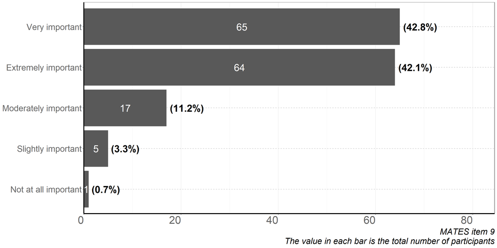

```r
# Separate rows and count total for Question 20
total_heterogeneity_importance_count <- dat %>%
  filter(!is.na(Q20)) %>%
  count(Q20) %>%
  arrange(desc(n))

# Calculate count as a percentage
total_heterogeneity_importance_percentage <-  total_heterogeneity_importance_count %>%
  mutate(proportion = n/sum(total_heterogeneity_importance_count$n),
         percentage = proportion*100)

# Plot for survey question 20
fig_Q20 <-  total_heterogeneity_importance_count %>%
  ggplot(aes(x = n, y = reorder(Q20, n)), hjust = 0.5) +
  geom_bar(stat = "identity") +
  geom_text(aes(label = n, x = n/2 , y = reorder(Q20, n)), hjust = 0.5, size = 8, color = "white") +
 geom_text(data = total_heterogeneity_importance_percentage, aes(label = paste0("(", round(percentage, 1), "%)"), x = n),
            hjust = -0.1, size = 8, color = "black", fontface = "bold") +
  scale_fill_identity(guide = "none") +
  scale_x_continuous(expand = c(0,0), limits = c(0, max(total_heterogeneity_importance_count$n*1.3))) +
  MATES_theme() +
  labs(caption = "MATES item 9\nThe value in each bar is the total number of participants")

fig_Q20
```

```r
# ggsave(here("survey_results", "fig_Q20.jpg"),  width = 16, height = 8, units = "cm", scale = 2, dpi = 120 )
```

## Question 21

Comments on MATES item 9 (e.g., potential improvements or a justification of response)

```r
# Filter for question 21
df_Q21 <- dat %>%
  filter(!is.na(Q21)) %>%
  select(c(Q20,Q21))

# Table for question 21
 kable(df_Q21, "html") %>%
    kable_styling("bordered", position = "left") %>%
    scroll_box(width = "150%", height = "400px")
```

| Q20 | Q21 |
| --- | --- |
| Slightly important | I think the importance of this depends on the research questions/aims and the research field. In some areas it would be expected that there is a lot of remaining heterogeneity in the data, so reportin… |
| Very important | It should be mentioned in the text and detailed in supplimentary materials. |
| Extremely important | Maybe add, ‘is is correctly described’ - they are often not correctly described. |
| Extremely important | Reporting a measure of heterogeneity between effect size estimates in a meta-analysis is important because it allows other researchers to understand how much the effect sizes vary across the studies i… |
| Very important | I think heterogeneity measures are commonly required for meta-analyses |
| Very important | Understand more about the assumptions and limitations |
| Moderately important | I am not so familiar with all of this - haven’t used it in my meta analysis… |
| Moderately important | Not sure of my response. Q and I2 are not well understood and interpreted I think. Many people reading Meta-analyses do not focus on this. + In ecological studies the between study heterogeneity is of… |
| Very important | Limitations an interpretation of heterogeneity tests should be discussed. |
| Extremely important | Unsure what is meant by measure of heterogeneity. Also, perhaps measure of heterogeneity is not as important as the clarity on the method for estimating the heterogeneity, the size of heterogeneity an… |
| Extremely important | The report of heterogeneity is important to correctly report and interpret data. |
| Extremely important | very important for later decision making |
| Not at all important | I assume heterogeneity by default so I’m just not that interested in testing for this. Put another way, if I’m going to use varying (aka random) effects in my model anyways because they’re more effici… |
| Very important | Could be useful to provide examples, like I2. |
| Very important | This practice assesses consistency among studies, providing information about the agreement or variation of results. An appropriate measure of heterogeneity enhances the interpretation of results and … |
| Extremely important | fundamental to assess if meta-analysis is feasible and reliable. |
| NA | So, by measure of heterogeneity, do you mean sd, se, range, 95%CI, etc.? |
| Very important | Important for interpretation and assessment of bias |
| Very important | Heterogeneity refers to the variability in effect sizes across different samples and is one of the major criteria to judge the importance and advancement of a scientific area. |
| Very important | would be interesting to know what measure is reported |
| Moderately important | I cannot answer this. I do not understand the question |
| Very important | Some statistical tests assume the homogeneity between effect size estimates. So, the authors must let the readers know how they deal with the heterogeneity. |

```r
# write_csv(df_Q21, file = here("survey_results", "df_Q21.csv"))
```

## Question 22

What is the importance of reporting the moderator variables included in a meta-regression in a meta-analysis to the quality of reporting?

Referring to MATES item 10:

Do the authors report the moderator variables included in a meta-regression within the manuscript or supplementary material?

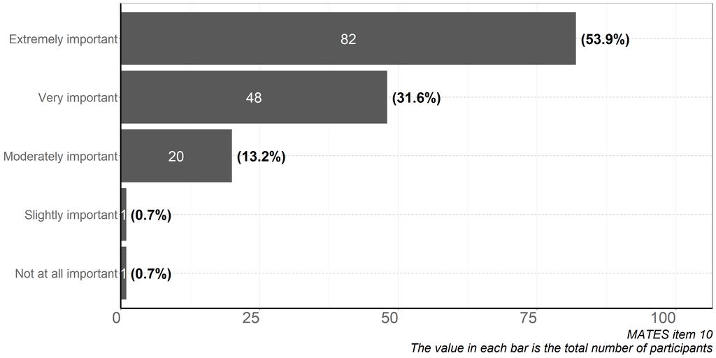

```r
# Separate rows and count total for Question 22
total_moderator_variables_importance_count <- dat %>%
  filter(!is.na(Q22)) %>%
  count(Q22) %>%
  arrange(desc(n))

# Calculate count as a percentage
total_moderator_variables_importance_percentage <-  total_moderator_variables_importance_count %>%
  mutate(proportion = n/sum(total_moderator_variables_importance_count$n),
         percentage = proportion*100)

# Plot for survey question 22
fig_Q22 <-  total_moderator_variables_importance_count %>%
  ggplot(aes(x = n, y = reorder(Q22, n)), hjust = 0.5) +
  geom_bar(stat = "identity") +
  geom_text(aes(label = n, x = n/2 , y = reorder(Q22, n)), hjust = 0.5, size = 8, color = "white") +
 geom_text(data = total_moderator_variables_importance_percentage, aes(label = paste0("(", round(percentage, 1), "%)"), x = n),
            hjust = -0.1, size = 8, color = "black", fontface = "bold") +
  scale_fill_identity(guide = "none") +
  scale_x_continuous(expand = c(0,0), limits = c(0, max(total_moderator_variables_importance_count$n*1.3))) +
  MATES_theme() +
  labs(caption = "MATES item 10\nThe value in each bar is the total number of participants")

fig_Q22
```

```r
# ggsave(here("survey_results", "fig_Q22.jpg"),  width = 16, height = 8, units = "cm", scale = 2, dpi = 120 )
```

## Question 23

Comments on MATES item 10 (e.g., potential improvements or a justification of response)

```r
# Filter for question 23
df_Q23 <- dat %>%
  filter(!is.na(Q23)) %>%
  select(c(Q22,Q23))

# Table for question 23
 kable(df_Q23, "html") %>%
    kable_styling("bordered", position = "left") %>%
    scroll_box(width = "150%", height = "400px")
```

| Q22 | Q23 |
| --- | --- |
| Extremely important | It shouldn’t be published without this. |
| Moderately important | Depended on the purpose of analysis, meta-regression may be carried out. |
| Very important | Reporting the moderator variables included in a meta-regression in a meta-analysis is important because it allows other researchers to understand how the effect sizes vary depending on the characteris… |
| Extremely important | Part of the model description - if moderators are used, they also need to be reported. |
| Very important | Understand the correlation of each variables |
| Moderately important | Depend on the aim/objective of the study. It could only be estimate the mean effect, size, or calculate the homogeneity/heterogeneity between effectsize and identify the moderators. In some cases, yes… |
| Extremely important | Without reporting them, different meta-regressions could give different results, so of course this should be required. |
| Extremely important | very important as testing the effect of these moderators is the point of conducting the meta-regression. |
| Extremely important | Very important, otherwise the metaregression doesn’t have much utility to the reader. |
| Very important | Whenever the data is available it is important to test for variables that could alter meta-analysis results or modulate data in a different direction/significance. But this should not be used to downg… |
| Extremely important | The only case I can imagine with NA making sense is a model with no moderators. It is quite rare but the option still exists, so I’d suggest to open up the possibility for an NA option |
| Extremely important | Preferably these are specified in a protocol already or clear justification is made why these were selected. However, here I would like to have the option NA in case meta-regression wasn’t performed. |
| Extremely important | Perhaps a bit tautological in that it is hard to imagine a scenario in which you wouldn’t do this |
| Moderately important | Although rare, there may be small meta-analyses without moderators, which will make this question irrelevant. Here, inspecting figures and the results section could help know what moderator variables … |
| Moderately important | Not all meta-analyses will have meta-regressions, so question should have an “if applicable”. |
| Extremely important | Reporting on moderating variables in a meta-regression in a meta-analysis is crucial for the quality of the scientific report. This provides a detailed understanding of how moderating variables influe… |
| Extremely important | Without knowing of moderator, meta-regression is not helpful |
| NA | Not familiar with “moderator” variable – are you talking about fixed/random effects in a meta-regression model? Overall, it would be helpful to have definitions, examples, and citations to the languag… |
| Extremely important | More important than reporting moderators would be the reasoning behind why those moderators were tested |
| Extremely important | Important for interpretation, assessment of bias and repeatability |
| Very important | to evaluate the con-founders and moderators in our main Meta-analysis effects. |
| Extremely important | Any items related to how the statistical analysis was done should be reported, especially when they can greatly influence the results. |
| Extremely important | If, what you call ‘moderator variable’ is what I would call confounding variable or interactive variable, that this is the most important of all points. See my earlier comments. Your phrasing reads a … |
| Extremely important | If a meta-regression is conducted it is of course extremely important to report the moderator variables, but that is not the same as saying that it is extremely important to conduct a meta-regression. |
| Extremely important | I guess including moderator variables would be part of the hypothesis that are to be tested, so reporting these would be essential |
| Extremely important | If moderators are included in a meta-regression, then yes, absolutely any and all moderators should be reported. These moderators should ALSO be clearly described/defined and include units/categories … |

```r
# write_csv(df_Q23, file = here("survey_results", "df_Q23.csv"))
```

## Question 24

What is the importance of reporting a test or measure of publication bias in a meta-analysis to the quality of reporting?

Referring to MATES item 11:

Do the authors report a test or measure of publication bias within the manuscript or supplementary material?

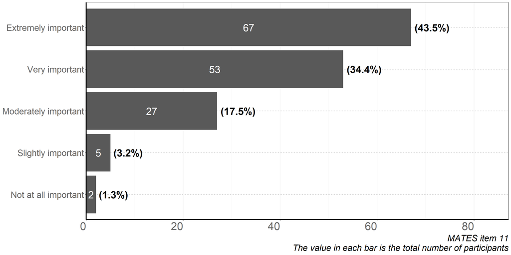

```r
# Separate rows and count total for Question 24
total_publication_bias_importance_count <- dat %>%
  filter(!is.na(Q24)) %>%
  count(Q24) %>%
  arrange(desc(n))

# Calculate count as a percentage
total_publication_bias_importance_percentage <-  total_publication_bias_importance_count %>%
  mutate(proportion = n/sum(total_publication_bias_importance_count$n),
         percentage = proportion*100)

# Plot for survey question 24
fig_Q24 <-  total_publication_bias_importance_count %>%
  ggplot(aes(x = n, y = reorder(Q24, n)), hjust = 0.5) +
  geom_bar(stat = "identity") +
  geom_text(aes(label = n, x = n/2 , y = reorder(Q24, n)), hjust = 0.5, size = 8, color = "white") +
 geom_text(data = total_publication_bias_importance_percentage, aes(label = paste0("(", round(percentage, 1), "%)"), x = n),
            hjust = -0.1, size = 8, color = "black", fontface = "bold") +
  scale_fill_identity(guide = "none") +
  scale_x_continuous(expand = c(0,0), limits = c(0, max(total_publication_bias_importance_count$n*1.3))) +
  MATES_theme() +
  labs(caption = "MATES item 11\nThe value in each bar is the total number of participants")

fig_Q24
```

```r
# ggsave(here("survey_results", "fig_Q24.jpg"),  width = 16, height = 8, units = "cm", scale = 2, dpi = 120 )
```

## Question 25

Comments on MATES item 11 (e.g., potential improvements or a justification of response)

```r
# Filter for question 25
df_Q25 <- dat %>%
  filter(!is.na(Q25)) %>%
  select(c(Q24,Q25))

# Table for question 25
 kable(df_Q25, "html") %>%
    kable_styling("bordered", position = "left") %>%
    scroll_box(width = "150%", height = "400px")
```

| Q24 | Q25 |
| --- | --- |
| Moderately important | In theory, I think this is important. But I don’t think it does its job. I’ve read a number of papers that state something like ‘we found evidence of publication bias, but we don’t think it’s much so … |
| Very important | This information is important for evaluating the results. |
| Moderately important | People should consider them for sure, I am less impressed by the actual measures. I would say have they considered publication bias, with a test if appropriate. |
| Very important | Reporting a sensitivity analysis in a meta-analysis is important because it allows other researchers to assess the robustness of the results to different assumptions and decisions. By reporting a sens… |
| Slightly important | Commonly done as part of the meta-analysis, but I am not sure how important it is. The tools available for testing publication bias are limited and not able to detect publication bias in many cases. |
| Very important | Check the robustness of the study |
| Very important | Yes, But not sufficient. If there is a publication biais. What do we do?? I would propose to better handle publication biais directly in the model(e.g. New method (e.g. robust bayesian meta-analysis;)… |
| Moderately important | I think this is one aspect that many authors still struggle with, and I think better explanations of how to include this in common statistical packages are needed |
| Very important | Consideration of publication bias is a key indicator of the quality of the review |
| Very important | Limitations and interpretation of publication bias tests should be discussed. Funnel plot asymmetry and assoicated test can be due to other factors in addition to small sample size |
| Slightly important | I don’t think this is very important as it is very difficult to assess publication bias with any degree of certainty. Surely all the information on the actual meta-analyses, the statistical models, th… |
| Extremely important | To ensure validity of the meta-analysis |
| Extremely important | Publication bias is a hughe problem, because non-significant resutls are rarely published, as well as results which do not match the scientists hypothesis. |
| Extremely important | it should be methodology for publication bias and estimated size of bias. |
| Not at all important | I’ve never been convinced this is a very valuable exercise. Publication bias surely exists, as does system selection, etc. |
| Extremely important | Assuming this includes visual assessments |
| Extremely important | Different studies with different methods are already a bias for a meta-analysis and the latter should be used in a set of studies with the best quality and not only the ones with the best results. |
| Moderately important | i am not sure how well they generally work, but i guess better than nothing |
| Moderately important | I did some meta-analyses where the variables that we were concerned with were just a few of dozens that were typically reported in the studies. They were rarely a principal item of interest to the aut… |
| Very important | The last time I checked, this is quite hard to achieve for models with moderators and non-independence |
| Extremely important | this should also include a justification if this is not possible (e.g. small sample size) |
| Extremely important | Does this mean that the answer will be “no” for articles reporting only a visual assessment of publication bias? It would be a good idea to clarify this point for future assessors. |
| Moderately important | I view all research as biased in some way, we can’t help it, so publication bias is sneaking around in virtually any meta-analysis. But I also don’t think it’s that straightforward to suss out and fun… |
| Extremely important | Essential; no further comment. |
| Extremely important | This activity is key to assessing the validity and reliability of the results, as publication bias can significantly alter conclusions. It provides transparency and demonstrates methodological rigor, … |
| Moderately important | Often a narrative discussion of this is more important, as the tests of PB are not the greatest. A lot of MA are really too small for any meaningful tests anyway. I would say ‘test or measure (if appr… |
| Extremely important | At least of main analyses, not all sensitivity and stratified analyses. |
| Very important | Important bias for the meta-analysis that should be considered |
| Very important | is part of the critical evaluation process |
| Extremely important | when studies with significant results are more likely to be published than non-significant findings – has dangerous consequences for meta-analyses. |
| Very important | I think the ideal situation is that publication bias is reported. But, in my opinion, it is also valid to mention in the paper that the authors are aware of publication bias, and that the analysis is … |
| Very important | would seem important to report biases of single studies (e.g. confounding, measurement bias, etc.) and assess their influences on meta-estimates of association; would also seem important to document i… |
| Extremely important | Again, if this refers to biased data handling (e.g. not stratifying data by things like age of people, or nutrition of plants, or experimental conditions such as indoor vs outdoor etc.) this is key. |
| Very important | Although it is important to report a test or measure of publication bias, it is as important to keep in mind that it is quite hard to test for publication bias and that all those measures may be inter… |
| Moderately important | Publication bias provides additional information (and potentially interesting insights into trends in the literature). If such trends are present they should be included in the analyses (as with any o… |
| Extremely important | Yep, this too is important. I sometimes feel researchers include this but they don’t really understand or interpret the measure properly. In fairness, interpretation of many pub bias tests are inheren… |

```r
# write_csv(df_Q25, file = here("survey_results", "df_Q25.csv"))
```

## Question 26

What is the importance of reporting a sensitivity analysis in a meta-analysis to the quality of reporting?

Referring to MATES items 12:

Do the authors report a sensitivity analysis in addition to a publication bias test within the manuscript or supplementary material?

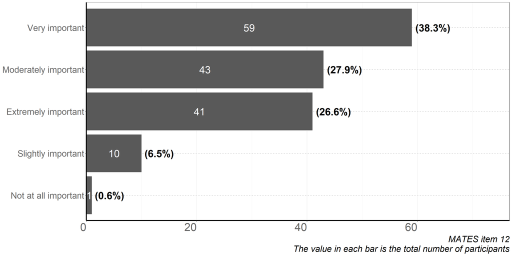

```r
# Separate rows and count total for Question 26
total_sensitivity_analysis_importance_count <- dat %>%
  filter(!is.na(Q26)) %>%
  count(Q26) %>%
  arrange(desc(n))

# Calculate count as a percentage
total_sensitivity_analysis_importance_percentage <-  total_sensitivity_analysis_importance_count %>%
  mutate(proportion = n/sum(total_sensitivity_analysis_importance_count$n),
         percentage = proportion*100)

# Plot for survey question 26
fig_Q26 <-  total_sensitivity_analysis_importance_count %>%
  ggplot(aes(x = n, y = reorder(Q26, n)), hjust = 0.5) +
  geom_bar(stat = "identity") +
  geom_text(aes(label = n, x = n/2 , y = reorder(Q26, n)), hjust = 0.5, size = 8, color = "white") +
 geom_text(data = total_sensitivity_analysis_importance_percentage, aes(label = paste0("(", round(percentage, 1), "%)"), x = n),
            hjust = -0.1, size = 8, color = "black", fontface = "bold") +
  scale_fill_identity(guide = "none") +
  scale_x_continuous(expand = c(0,0), limits = c(0, max(total_sensitivity_analysis_importance_count$n*1.3))) +
  MATES_theme() +
  labs(caption = "MATES item 12\nThe value in each bar is the total number of participants")

fig_Q26
```

```r
# ggsave(here("survey_results", "fig_Q26.jpg"),  width = 16, height = 8, units = "cm", scale = 2, dpi = 120 )
```

## Question 27

Comments on MATES item 12 (e.g., potential improvements or a justification of response)

```r
# Filter for question 27
df_Q27 <- dat %>%
  filter(!is.na(Q27)) %>%
  select(c(Q26,Q27))

# Table for question 27
 kable(df_Q27, "html") %>%
    kable_styling("bordered", position = "left") %>%
    scroll_box(width = "150%", height = "400px")
```

| Q26 | Q27 |
| --- | --- |
| Moderately important | I think this again depends on the research question and aims. If there is a clear reason to run a sensitivity analysis then yes, this should be reported. But I could imagine in some cases, this might … |
| Moderately important | It may be described in supplimentary materials. |
| Moderately important | This is so contextual, again I would probably say ‘have they considered the need for sensitivity analyses and reported if necessary’ |
| Extremely important | Reporting the total number of studies included in the meta-analysis is important because it allows readers to assess the comprehensiveness of the review and the size of the evidence base. This informa… |
| Moderately important | it depends on the case, if there are several possible outliers it becomes important |
| Very important | Important to check which factors influence the results most |
| Very important | Check the robustness of the model/parameters |
| Very important | For me sensitivity analysis are totally different from publication bias. sensitivity analysis are for testing the hypothesis of the model structure, impact of missing data, type of inference (bayesian… |
| Slightly important | Same comments as the last question |
| Moderately important | This may not be applicable to all reviews but is important to include where relevant |
| Extremely important | If it applicable, then should be reported. Otherwise, no. |
| Extremely important | Sensitivity analyses, to me ,is more important than publication bias test |
| Moderately important | I think this makes much more sense than the publication bias tests. But it depends on the context so it is not motivated in all cases. |
| Extremely important | Formualtion of the question could be clearer “report a sensitivity analysis” or perhaps “report details of methods for and outcomes of sensitivity analysis”. |
| Slightly important | Depends on the data and if there are indications a small number of studies might be mighty influential |
| Extremely important | This and the bias measure are both essential parts of the theory of meta-analysis. Most of the things which have gone before are more broadly applicable to statistical projects, but this gets to the c… |
| Extremely important | The sensitivity analysis is important to test for the reliability of the obtained results. |
| Slightly important | sensitivity to what? too vague… |
| Extremely important | With the provisos indicated for other questions |
| Very important | I am not sure what this means ‘sensitivity analysis’ - sensitivity of what? this could be important or not important at all depending on the definition of this |
| Moderately important | In a way, ‘sensitivity’ is addressed by measures such as cross-validation, it just may not be labelled as such. In any case, ‘sensitivity analysis’ needs to be clarified for what specific part of the … |
| Very important | I am confused why the item refers to “sensitivity analysis IN ADDITION to a publication bias test”. These are often very different tests, and should be considered separately. |
| Slightly important | Doesn’t necessarily apply to all meta-analyses, so should have an “if applicable”. |
| Very important | Conducting and reporting a sensitivity analysis in a meta-analysis is essential for the quality of the scientific report. This analysis assesses the robustness of the results against variations in met… |
| Very important | If appropriate |
| Extremely important | In meta-analysis, different estimate method may produce largely different results. |
| Slightly important | Do all meta-analyses conduct sensitivity analyses? My guess is maybe not. So, if they didn’t conduct one and therefore didn’t report it, then does that count against them in some way? |
| Very important | The reason I chose very important,and not extremely important, is that I haven’t conducted sensitivity analysis in my meta-analysis. From those I read, the presence of sensitivity analysis felt like a… |
| Not at all important | This lends itself to assessing the bias of the meta-analysis, not the reporting as such as it relates to the conduct of the analysis. Important to distinguish. |
| Moderately important | if ther eis sensitivity it is important. This is not always the case |
| Very important | A sensitivity analysis is usually included in a meta-analysis because of uncertainty regarding the effectiveness or safety of an intervention. Sensitivity analyses are purposed to gain insight and cer… |
| Very important | i would be more specific and ask whether authors assessed the influence of residual confounding or biases on the meta-estimate |
| Extremely important | sure you want to see the power of the analysis, for instance how sensitive the analysis is with regard to the inclusion or exclusion of certain criteria by which the data were stratified (sorted) |
| Very important | Here you may want to be a bit more specific about what the sensitivity analysis should be based on (e.g., critical appraisal assessment or other subgroups). Also, do you include for example fail-safe … |
| Extremely important | Sensitivity analyses provide valuable information because even the most detailed meta-analysis can let outside other sources of information. So, knowing which results are less or more sensitive to exc… |
| Moderately important | In answering this question I am a little biased, because in a recent meta-analysis we tried to use the critical appraisal tool for study validity assessment proposed by Konno et al (2021) and that did… |

```r
# write_csv(df_Q27, file = here("survey_results", "df_Q27.csv"))
```

## Question 28

What is the importance of reporting the total number of studies included in the meta-analysis to the quality of reporting?

Referring to MATES item 13:

Do the authors report the total number of studies within the manuscript or supplementary material?

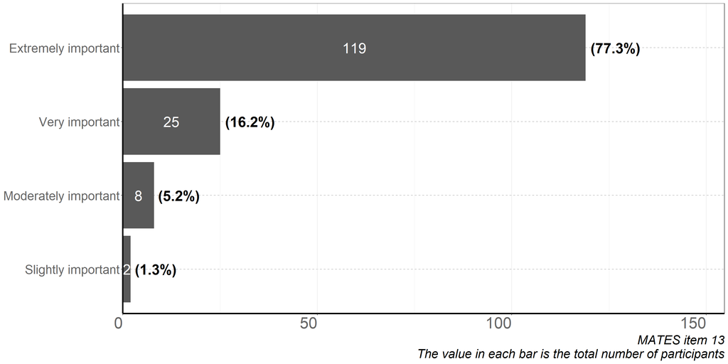

```r
# Separate rows and count total for Question 28
total_studies_included_count <- dat %>%
  filter(!is.na(Q28)) %>%
  count(Q28) %>%
  arrange(desc(n))

# Calculate count as a percentage
total_studies_included_percentage <-  total_studies_included_count %>%
  mutate(proportion = n/sum(total_studies_included_count$n),
         percentage = proportion*100)

# Plot for survey question 28
fig_Q28 <-  total_studies_included_count %>%
  ggplot(aes(x = n, y = reorder(Q28, n)), hjust = 0.5) +
  geom_bar(stat = "identity") +
  geom_text(aes(label = n, x = n/2 , y = reorder(Q28, n)), hjust = 0.5, size = 8, color = "white") +
 geom_text(data = total_studies_included_percentage, aes(label = paste0("(", round(percentage, 1), "%)"), x = n),
            hjust = -0.1, size = 8, color = "black", fontface = "bold") +
  scale_fill_identity(guide = "none") +
  scale_x_continuous(expand = c(0,0), limits = c(0, max(total_studies_included_count$n*1.3))) +
  MATES_theme() +
  labs(caption = "MATES item 13\nThe value in each bar is the total number of participants")

fig_Q28
```

```r
# ggsave(here("survey_results", "fig_Q28.jpg"),  width = 16, height = 8, units = "cm", scale = 2, dpi = 120 )
```

## Question 29

Comments on MATES item 13 (e.g., potential improvements or a justification of response)

```r
# Filter for question 29
df_Q29 <- dat %>%
  filter(!is.na(Q29)) %>%
  select(c(Q28,Q29))

# Table for question 29
 kable(df_Q29, "html") %>%
    kable_styling("bordered", position = "left") %>%
    scroll_box(width = "150%", height = "400px")
```

| Q28 | Q29 |
| --- | --- |
| Very important | It provides a framework for interpreting the results. More important is publishing the data somewhere. |
| Extremely important | Absolutely important information. |
| Extremely important | Basic information, must include this. |
| Very important | This is important so that the reader knows to which extend data was available - Not sure how study is defined here - Can one study include several effect sizes? Should be specified. |
| Very important | Understand the sampling size |
| Moderately important | I would tend to focus more on the accuracy of the estimated effects (i.e., mean effect, confidence intervals, heterogeneity, etc.). For me, the number of included studies is often a “headline effect”,… |
| Extremely important | There should be a list of all studies, not only the total number. I have bene involved in instances were a different research group have tried to replicate a meta-analysis done by another group, and w… |
| Extremely important | This is a fundamental piece of information for the methods of a systematic review. Ideally the full references of every included study should also be available. |
| Extremely important | This is a key element. |
| Extremely important | It is important to discuss criteria for selection of studies and selection of risk estimates. Also meta-analysis should not be done on small numbers of studies |
| Extremely important | Very fundamental information that simply must be there. |
| Extremely important | a very basic information needed to give an idea of the comprehensiveness of the search and available studies. |
| Extremely important | Pivotal to the quality of reporting so the reader knows the breadth of studies in the analyses |
| Extremely important | It’s important that you clarify what is meant by study. I find this is a chronic source of confusion. It it a paper? An experiment? An effect size? Something else? |
| Very important | It helps readers contextualise the synthesis in terms of the knowledge base. |
| Extremely important | The higher the number the higher the strengh of the meta-analysis and this is a basic reporting that needs to be disclose in every review |
| Extremely important | Essential. No further comment. |
| Extremely important | Reporting the total number of studies in a meta-analysis is vital for the quality of the scientific report. This information provides insight into the breadth and representativeness of the evidence re… |
| Extremely important | Mandatory to evaluate what studies are assessed and included compared to those not. |
| Extremely important | Important for interpretation and repeatability |
| Very important | Useful for defining the research question, data collection, data preparation, data analysis, and reporting and meta-analysis. |
| Extremely important | This is basic information and should be included. Analyzing 3 vs. 35 papers will have different implications for statistics and robustness. |
| Extremely important | is it really a question to ask - would anyone perform a meta-analysis without reporting the n? |
| Extremely important | Trivial, of course you need to describe your sample and what its structure is |
| Extremely important | This is related to the previous question. The readers need to know how many studies were included in the meta-analysis because slight differences in the number of studies can lead to distinct results … |
| Extremely important | Again, this goes back to the transparency of reporting :) |
| Extremely important | I think it is also important to define what they used as a ‘study’. Sometimes the study could be the primary paper itself, but sometimes there could be multiple case studies reported in a single prima… |

```r
# write_csv(df_Q29, file = here("survey_results", "df_Q29.csv"))
```

## Question 30

What is the importance of reporting the total number of effect size estimates included in the meta-analysis to the quality of reporting?

Referring to MATES item 14:

Do the authors report the total number of effect sizes within the manuscript or supplementary material?

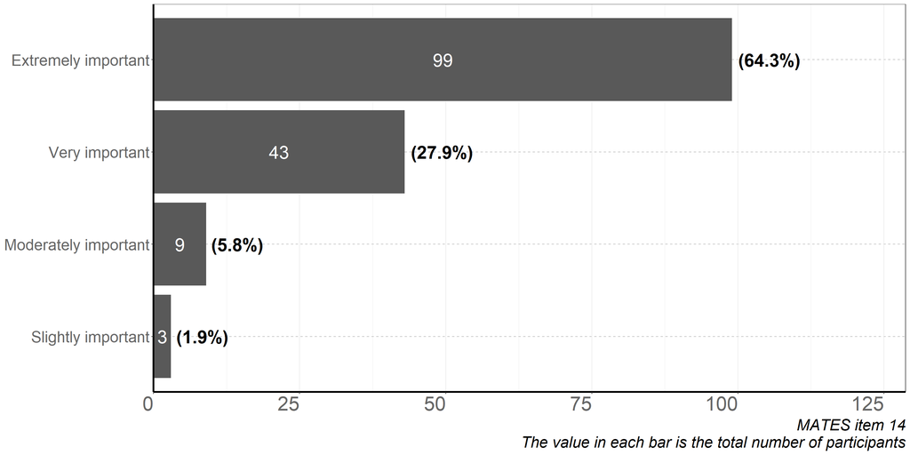

```r
# Separate rows and count total for Question 30
total_effect_size_count <- dat %>%
  filter(!is.na(Q30)) %>%
  count(Q30) %>%
  arrange(desc(n))

# Calculate count as a percentage
total_effect_size_percentage <-  total_effect_size_count %>%
  mutate(proportion = n/sum(total_effect_size_count$n),
         percentage = proportion*100)

# Plot for survey question 30
fig_Q30 <-  total_effect_size_count %>%
  ggplot(aes(x = n, y = reorder(Q30, n)), hjust = 0.5) +
  geom_bar(stat = "identity") +
  geom_text(aes(label = n, x = n/2 , y = reorder(Q30, n)), hjust = 0.5, size = 8, color = "white") +
 geom_text(data = total_effect_size_percentage, aes(label = paste0("(", round(percentage, 1), "%)"), x = n),
            hjust = -0.1, size = 8, color = "black", fontface = "bold") +
  scale_fill_identity(guide = "none") +
  scale_x_continuous(expand = c(0,0), limits = c(0, max(total_effect_size_count$n*1.3))) +
  MATES_theme() +
  labs(caption = "MATES item 14\nThe value in each bar is the total number of participants")

fig_Q30
```

```r
# ggsave(here("survey_results", "fig_Q30.jpg"),  width = 16, height = 8, units = "cm", scale = 2, dpi = 120 )
```

## Question 31

Comments on MATES item 14 (e.g., potential improvements or a justification of response)

```r
# Filter for question 31
df_Q31 <- dat %>%
  filter(!is.na(Q31)) %>%
  select(c(Q30,Q31))

# Table for question 31
 kable(df_Q31, "html") %>%
    kable_styling("bordered", position = "left") %>%
    scroll_box(width = "150%", height = "400px")
```

| Q30 | Q31 |
| --- | --- |
| Very important | It provides a framework for interpreting the results. More important is publishing the data somewhere. |
| Very important | Such information is definitely needed. |
| Extremely important | Same as before, need to know this. |
| Moderately important | Are effect sizes the values which are used vor meta-analysis? I guess this number is reported with the outcome of each analysis anyway, or not? |
| Very important | Understand the sampling size |
| Very important | Important in the forest plot associated to each effect-size. |
| Extremely important | Again very fundamental information on the underlying data. |
| Extremely important | I also think it’s important to report the number of effect sizes extracted from each study (e.g., mean +/- SD, range) to show where the data are coming from. Especially important for smaller meta-anal… |
| Very important | As before (but understanding multiple effect sizes can come from a single publication). |
| Extremely important | The number of included studies could differ from the ones used for each estimated meta-data, so it is important to report effect size estimates |
| Very important | Important, but probably not as important as the number of studies. |
| Extremely important | Reporting the total number of effect size estimates in a meta-analysis is essential for the quality of the scientific report. This information provides a clear view of the magnitude and diversity of t… |
| Extremely important | This should be mandatory if me-analysis is implemented |
| Extremely important | Both n and k helps researchers better understand the non-independence claims |
| Extremely important | important for assessing potential bias and repeatability |
| Very important | Effect size reporting is crucial for interpretation of applied research results and for conducting meta-analysis. |
| Very important | Contributes to transparency and reproducibility. |
| Extremely important | seems redundant with previous question |
| Extremely important | there should be no such analysis without descriptive stats upfront |
| Extremely important | Same as comment Q30 - important to report total number but also important to define what an effect size was in their analysis (this also relates the independence of effect sizes) - this is needed to u… |

```r
# write_csv(df_Q31, file = here("survey_results", "df_Q31.csv"))
```

## Question 32

What is the importance of reporting the results using a visualisation in a meta-analysis to the quality of reporting?

Referring to MATES item 15:

Do the authors report the results using a visualisation in the manuscript or supplementary material?

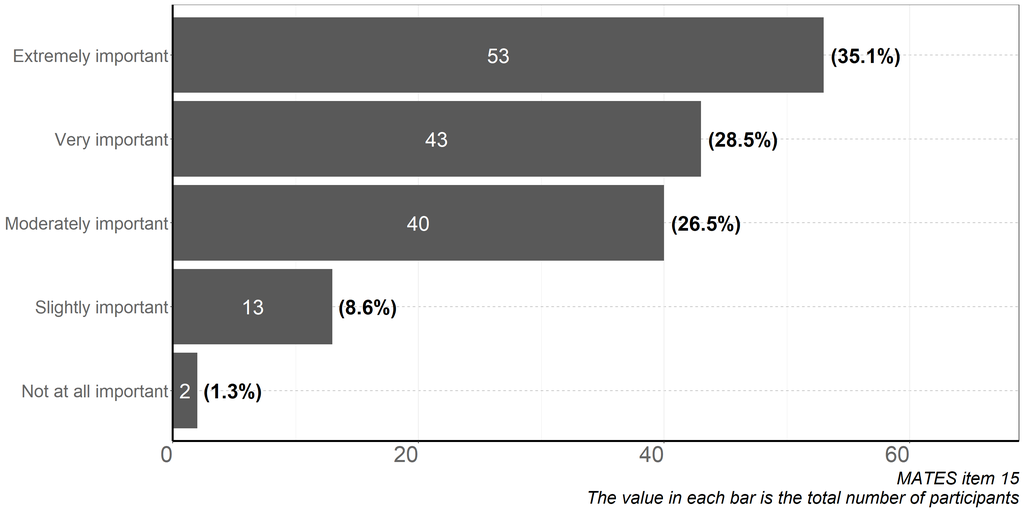

```r
# Separate rows and count total for Question 32
total_visualisation_report_count <- dat %>%
  filter(!is.na(Q32)) %>%
  count(Q32) %>%
  arrange(desc(n))

# Calculate count as a percentage
total_visualisation_report_percentage <-  total_visualisation_report_count %>%
  mutate(proportion = n/sum(total_visualisation_report_count$n),
         percentage = proportion*100)

# Plot for survey question 32
fig_Q32 <-  total_visualisation_report_count %>%
  ggplot(aes(x = n, y = reorder(Q32, n)), hjust = 0.5) +
  geom_bar(stat = "identity") +
  geom_text(aes(label = n, x = n/2 , y = reorder(Q32, n)), hjust = 0.5, size = 8, color = "white") +
 geom_text(data = total_visualisation_report_percentage, aes(label = paste0("(", round(percentage, 1), "%)"), x = n),
            hjust = -0.1, size = 8, color = "black", fontface = "bold") +
  scale_fill_identity(guide = "none") +
  scale_x_continuous(expand = c(0,0), limits = c(0, max(total_visualisation_report_count$n*1.3))) +
  MATES_theme() +
  labs(caption = "MATES item 15\nThe value in each bar is the total number of participants")

fig_Q32
```

```r
# ggsave(here("survey_results", "fig_Q32.jpg"),  width = 16, height = 8, units = "cm", scale = 2, dpi = 120 )
```

## Question 33

Comments on MATES item 15 (e.g., potential improvements or a justification of response)

```r
# Filter for question 33
df_Q33 <- dat %>%
  filter(!is.na(Q33)) %>%
  select(c(Q32,Q33))

# Table for question 33
 kable(df_Q33, "html") %>%
    kable_styling("bordered", position = "left") %>%
    scroll_box(width = "150%", height = "400px")
```

| Q32 | Q33 |
| --- | --- |
| Slightly important | I think visualisations (I’m assuming you are talking about plots) are helpful for readers but if some models are poorly supported, then reporting that doesn’t need to be done visually. Also a table is… |
| Slightly important | Visualizaiton may help to understand the results. |
| Extremely important | Forest plot must be in the main text. With regards to other graphics, if it is vital for understanding the results it must be in the main paper, supplementary material must be just that. I would say ‘… |
| Moderately important | Depends on the number of analyses that need to be reported. If there is only one analysis, then a visual may not be needed. If there are different analyses, then a table or graph helps for sure. |
| Extremely important | Provide a better grasp of the output |
| NA | I am not sure to totally understand the question. Do the authors present a forest plot, or other type of plot? Yes, important to better communicate the results. But in some cases, graphical presentati… |
| Slightly important | could tables and figures be explicitly described here? would there be examples so that the appraiser knows what this mean |
| Slightly important | This is more a question of how accessible the material is. If all the data are availble, it’s of course possible to visualize so the most important is that the needed data is included. And this may al… |
| Very important | Depends on the meta-analysis, I think. |
| Moderately important | A figure will simplify the message for easier and faster understanding, but not that crucial as long as the results were part of the text |
| NA | This question could be more specific, providing examples of good visualisation options. |
| Moderately important | Important to show the spread of the data, less so for the absolute meta-analytical means and confidence intervals. |
| Slightly important | Formulation unclear. |
| Moderately important | It depends on the context. Some results are easily summarized in the text without the need for a figure. |
| Moderately important | It can be helpful but isn’t strictly neccessary |
| Extremely important | Extremely important to the reader to verify if the interpretation of the authors are correct. |
| Moderately important | summary statistics in the text can be sufficient for simple analyses of mean effects, but visualization nice to ensure patterns arent driven by outliers |
| NA | I honestly didn’t understand the question “Do the authors report the results using a visualisation in the manuscript or supplementary material?” when I read it first in your spreadsheet. I though that… |
| Extremely important | It might be hard to understand for some people what a data visualisation is, but it is very important to allow checking how the data are distributed across the ranges/levels of moderators |
| Moderately important | I think we are used to seeing results presented in visual formats and they do add value, e.g. in terms of distribution of effect sizes and CIs plus might show interesting patterns that wouldn’t be eas… |
| Slightly important | as long as results are presented clearly, the way of presenting does not matter |
| Moderately important | If the appropriate summary statistics are given, then of course this is not necessary, but it is extremely useful to get a general picture of the results quickly |
| Slightly important | As long as the results are reported (in the form of text or using a visualisation) I think that’s fine |
| Extremely important | I could understand why people would not rate this as “extremely important” because if people report e.g., the mean, confidence intervals, and heterogeneity, then most of the results are already presen… |
| Very important | No additional comment. |
| Very important | Visualizations such as forest plots or funnel diagrams significantly enhance the understanding and communication of complex results, effectively summarizing key patterns and trends. These tools make f… |
| Extremely important | It makes it easier to understand. A figure is easier to read than a table or text. |
| Extremely important | Data in figures are very easy to read compared to tables. |
| Moderately important | Again, define what you mean by visualization. Does that include tables? Or are you just talking about figures? |
| Not at all important | Visualisations can aid the reader, but aren’t necessarily required in the reporting of a meta-analysis. This is more a decision related to how best to tell the story, rather than something that’s righ… |
| Moderately important | it is useful, and make sthe data more insightful. It is not crucial for the quality or interpretation as such. |
| Very important | Visualization helps us see the story the data is telling, enabling highly effective reporting practices. |
| Slightly important | We usually use forest plots. |
| Slightly important | Having text and plots makes a paper more digestable, but I don’t think this is crucial for the overall quality. |
| Moderately important | nice to have, but if it hides or masks things because of two dimensional description of what is multidimensional they can also disguise the reality |
| Extremely important | At least for me, a visual presentation of the obtained results is easy to understand and compare. |
| Very important | Visualization tools are always helpful :) |
| Very important | Definitely very helpful to include visualizations of results but at minimum results of analyses should be described in text/tables. In the example provided for this item, may be put the visualization … |

```r
# write_csv(df_Q33, file = here("survey_results", "df_Q33.csv"))
```

## Question 34

What is the importance of reporting the data extracted in the meta-analysis to the quality of reporting?

Referring to MATES item 16:

Do the authors report the data extracted from each eligible primary study within the manuscript, supplementary material or external repository?

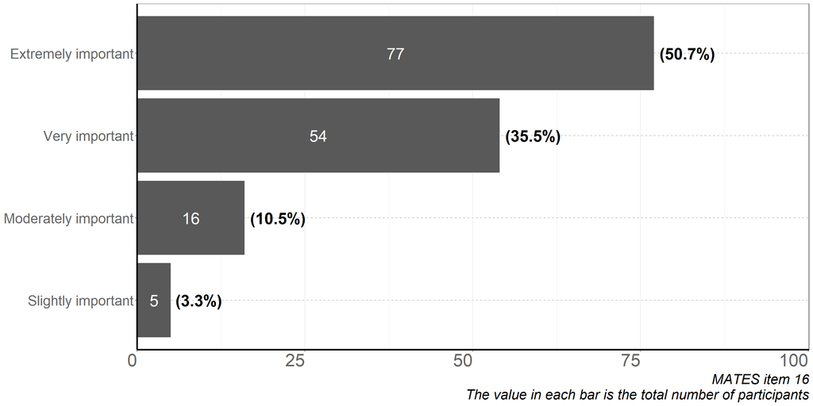

```r
# Separate rows and count total for Question 34
total_data_extraction_report_count <- dat %>%
  filter(!is.na(Q34)) %>%
  count(Q34) %>%
  arrange(desc(n))

# Calculate count as a percentage
total_data_extraction_report_percentage <-  total_data_extraction_report_count %>%
  mutate(proportion = n/sum(total_data_extraction_report_count$n),
         percentage = proportion*100)

# Plot for survey question 34
fig_Q34 <-  total_data_extraction_report_count %>%
  ggplot(aes(x = n, y = reorder(Q34, n)), hjust = 0.5) +
  geom_bar(stat = "identity") +
  geom_text(aes(label = n, x = n/2 , y = reorder(Q34, n)), hjust = 0.5, size = 8, color = "white") +
 geom_text(data = total_data_extraction_report_percentage, aes(label = paste0("(", round(percentage, 1), "%)"), x = n),
            hjust = -0.1, size = 8, color = "black", fontface = "bold") +
  scale_fill_identity(guide = "none") +
  scale_x_continuous(expand = c(0,0), limits = c(0, max(total_data_extraction_report_count$n*1.3))) +
  MATES_theme() +
  labs(caption = "MATES item 16\nThe value in each bar is the total number of participants")

fig_Q34
```

```r
# ggsave(here("survey_results", "fig_Q34.jpg"),  width = 16, height = 8, units = "cm", scale = 2, dpi = 120 )
```

## Question 35

Comments on MATES item 16 (e.g., potential improvements or a justification of response)

```r
# Filter for question 35
df_Q35 <- dat %>%
  filter(!is.na(Q35)) %>%
  select(c(Q34,Q35))

# Table for question 35
 kable(df_Q35, "html") %>%
    kable_styling("bordered", position = "left") %>%
    scroll_box(width = "150%", height = "400px")
```

| Q34 | Q35 |
| --- | --- |
| Very important | Detailed data extracted should be attached, with the consideration of copyright. |
| Extremely important | Important for replicability |
| Extremely important | I think raw data should be available for transparency and reproducibility. This should be a major feature of meta-analyses |
| Very important | Data transparency is important in simulation/modeling |
| Extremely important | yes, for transparency, reproducibility, and to update the database. Science is cumulative. I Think there is a big problem in science now for not to publish the database. |
| Extremely important | In order to repeat the meta-analysis, ideally the same data extractions would be used. |
| Slightly important | This is important for the context of open research and helping future researchers and also allows source data to be checked. |
| Moderately important | sometimes you can not report the all extracted data, due to some limitation. But details of search strategy must be report with details. |
| Extremely important | Very important for the possibility to reproduce or verify the analysis. |
| Extremely important | Definitely! For reproducibility of the research, for open science |
| Extremely important | Extremely important to know what actual data (which response traits) were extracted from each study. |
| Extremely important | It’s relatively common to provide effect sizes. I think it is much more valuable to report the data used to obtain the effect size. |
| Very important | Again general reproducibility. |
| Extremely important | The data extraction is the basis for the begging of data retrieval and needs to be carefully conducted to enable the correct choice of variables and methods to be used in the meta-analysis. |
| Extremely important | I mean, why not, but then again, do journals ask for all your data for all published primary articles? |
| Moderately important | ’-Might very be hard to do if the authors have requested data to the authors of individual studies and there is potential conflict in terms of authorship/ data ownewship -The question should be more s… |
| Very important | In general, data should be available. |
| Very important | Not entirely clear in this wording if it refers to simply reporting what variables are extracted in a methods sense, or if it means depositing the raw data somewhere, or even if reproducible image ext… |
| Extremely important | I think it’s also important to report effect size estimates with the data extracted |
| Extremely important | I’m very glad to see this item. It’s so disappointing how rare meta-analyses in my field actually include data! And it’s not even the authors’ data, it’s someone else’s! And it’s usually paid for by p… |
| Extremely important | Absolutely essential. Should also be provided in raw (i.e., direct from manuscript in original format) and harmonised formats, if possible. |
| Extremely important | failure to report the data is discussing a paper which has no results section. The secondary data upon which the analysis is done is extremely important |
| Very important | This ensures transparency and allows for the reproducibility of the analysis, fundamental elements for the integrity of scientific research. Providing details about the extracted data, such as sample … |
| Very important | A list may be enough, considering that is generally similar across reviews, but such brief list should be mandatory, extensive list is fine for supplementary material |
| Extremely important | Important to guarantee transparency and reproducibility |
| Extremely important | Important for assessing potential bias, interpretation and repeatability |
| Very important | Extracting data from studies is the norm in meta-analyses, enabling researchers to generate effect sizes when raw data are otherwise not available. |
| NA | It seems better to distinguish primary and secondary data extracted. |
| Moderately important | Good for transparency and reproducibility, but not crucial for the overall quality. |
| Extremely important | you mean descriptive stats upfront? The raw tables with what had been entered into the analysis must be reported in supplementary archives. That archive should already structured in a way how the data… |
| Extremely important | If anyone wants to reproduce the meta-analysis, sharing the original sources and the raw database is extremely important. |
| Moderately important | I find it useful to include this information as supplementary materials |

```r
# write_csv(df_Q35, file = here("survey_results", "df_Q35.csv"))
```

## Question 36

What is the importance of reporting the descriptions of data created in the meta-analysis to the quality of reporting?

Referring to MATES item 17:

Do the authors report descriptions of the data extracted from each eligible within the manuscript, supplementary material or external repository?

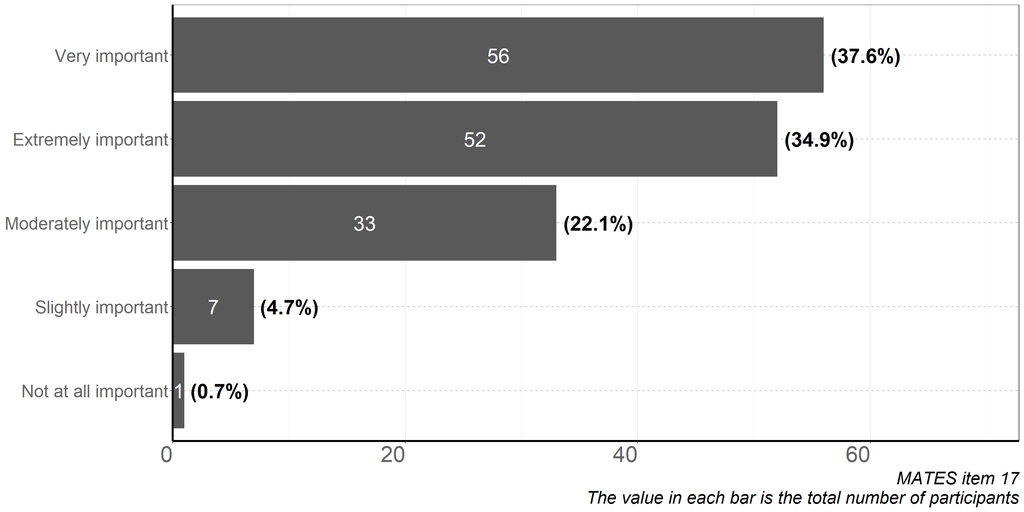

```r
# Separate rows and count total for Question 36
total_data_description_report_count <- dat %>%
  filter(!is.na(Q36)) %>%
  count(Q36) %>%
  arrange(desc(n))

# Calculate count as a percentage
total_data_description_report_percentage <-  total_data_description_report_count %>%
  mutate(proportion = n/sum(total_data_description_report_count$n),
         percentage = proportion*100)

# Plot for survey question 36
fig_Q36 <-  total_data_description_report_count %>%
  ggplot(aes(x = n, y = reorder(Q36, n)), hjust = 0.5) +
  geom_bar(stat = "identity") +
  geom_text(aes(label = n, x = n/2 , y = reorder(Q36, n)), hjust = 0.5, size = 8, color = "white") +
 geom_text(data = total_data_description_report_percentage, aes(label = paste0("(", round(percentage, 1), "%)"), x = n),
            hjust = -0.1, size = 8, color = "black", fontface = "bold") +
  scale_fill_identity(guide = "none") +
  scale_x_continuous(expand = c(0,0), limits = c(0, max(total_data_description_report_count$n*1.3))) +
  MATES_theme() +
  labs(caption = "MATES item 17\nThe value in each bar is the total number of participants")

fig_Q36
```

```r
# ggsave(here("survey_results", "fig_Q36.jpg"),  width = 16, height = 8, units = "cm", scale = 2, dpi = 120 )
```

## Question 37

Comments on MATES item 17 (e.g., potential improvements or a justification of response)

```r
# Filter for question 37
df_Q37 <- dat %>%
  filter(!is.na(Q37)) %>%
  select(c(Q36,Q37))

# Table for question 37
 kable(df_Q37, "html") %>%
    kable_styling("bordered", position = "left") %>%
    scroll_box(width = "150%", height = "400px")
```

| Q36 | Q37 |
| --- | --- |
| Very important | Fundamentally important. |
| Extremely important | As before - for replicability |
| Very important | Together with the effect size, all kinds of meta-data are usually reported in a database or table. |
| Moderately important | As long as the data is transparent with appropriate references, the descriptions of data extraction somehow not quite important |
| Extremely important | should be completely transparent! |
| NA | I am not sure to understand this question. |
| Moderately important | Not sure exactly what is meant here: but for example if there is a study with two different measurements of growth that need to be extracted, then notes on how this was dealt with should be included i… |
| Moderately important | It is important to clearly understand exactly which data were extracted from studies including details such as units |
| Extremely important | Perhaps be more specific about what is meant by ‘descriptions of the data’ |
| Moderately important | Important for reproducibility as readers may not understand the data without descriptors. |
| Extremely important | reference |
| NA | What is meant by ” descriptions of the data extracted from each eligible”? this is rather unclear. |
| Extremely important | It’s unclear what you mean by “from each eligible within..” |
| Very important | The descriptions of data created in the meta-analysis are the basics for correct interpretation of the graphics, does not need to be very extensive. |
| Extremely important | not sure what you mean by descriptions. I dont think they need to describe in words each study. Rather the sort of data that they were looking for using defined inclusion criteria that apply across st… |
| NA | Missing a word - Do the authors report descriptions of the data extracted from each eligible STUDY within the manuscript, supplementary material or external repository? |
| Moderately important | ’-The yes and no and NA responses include question marks, which they shouldn’t |
| Extremely important | Helps to understand the details of the study and how data was coded during the review process. |
| Very important | unclear what is referred to with “descriptors” Important, but possible to go back to the original publication if needed |
| Moderately important | Should be “from each eligible study”. And I suppose this means I misinterpreted the previous question, if this item is descriptions. Some clarification of how item 16 and 17 are distinct and what they… |
| Very important | Very important to contextualize the results of the meta-analysis |
| Very important | This is usually pretty helpful. I don’t give it ‘extremely’ important just because there could be some cases where, for brevity’s sake, a data description may not be given but if the dataset is availa… |
| Very important | A word is missing after “eligible”, I assume the word “study”? By “description” I assume you mean metadata describing each column of the data? |
| NA | Not sure what this question is asking. Is it a tabled summaries of results? |
| Moderately important | I consider this as not very important when assessing the reporting quality but adding this information will improve the transparency of the review methodology. |
| Very important | Not all papers have the methodology and that may induce differences in papers that are due mainly to methodology. This could induce a bias. |
| Very important | Helpful to assess missing data among the data required for inclusion. |
| Extremely important | Important for assessing bias |
| Very important | Evaluating the quality of reporting enables interpretation of the current quality of evidence and thus the current state and clinical relevancy. |
| Moderately important | Good for transparency and clarity. |
| Extremely important | I think this refers to the before mentioned archive. The listing must show the criteria (codes) by which the data were stratified in the analysis |
| Extremely important | Very important for reuse of the databases, so that all the work behind compiling them can be used more effectively |
| Extremely important | THIS IS HUGELY IMPORTANT IMHO! |

```r
# write_csv(df_Q37, file = here("survey_results", "df_Q37.csv"))
```

## Question 38

Are there any elements of meta-analyses that are considered important to reporting quality that are not currently included in MATES?

```r
# Filter for question 38
df_Q38 <- dat %>%
  filter(!is.na(Q38)) %>%
  select(Q38)

# Table fpr question 38
 kable(df_Q38, "html") %>%
    kable_styling("bordered", position = "left") %>%
    scroll_box(width = "150%", height = "400px")
```

Q38

I don’t have access to MATES material, so I can’t comment on that subject.

No.

This may be beyond the reach of the tool, but I would like items of the correct interpretation of the models (fixed/random) and the heterogeneity statistics.  
State the null/hypothesis maybe?  
Use of prediction intervals if appropriate

PRISMA graph and a PICO, as it contains the search terms, the planned statistics and variables, with the results of each sorting phase

A few thoughts: - perhaps some criteria around the literature search should be included? E.g. does the study state the literature selection criteria, search terms, literature databases used, inclusion/exclusion criteria - clear definitions/criteria of treatment vs control groups? - choice of effect size (e.g. SMD) and justification? - a clear statement of any random effects and nesting of random effects?

Conflicts of interest: Reporting of conflicts of interest is important for assessing the credibility of the meta-analysis.

Funding sources: Reporting of funding sources is important for assessing the potential for bias in the meta-analysis

Protocol registration: Registration of the meta-analysis protocol is important for reducing the risk of bias

none

The MATES only focuse on the statistical procedure. A key requisite is having a clear and reasonable proposal, including research question, search strategy, inclusion and excusion criteria, etc.

None

A very important part of systematic reviews is the critical appraisal of each datapoint used for analysis. Quality criterial need to be defined and each data point should be subjected to those criteria. Authors need to describe how they deal with data points that were rated as problematic in one or more criteria. Such data points could either be excluded altogether, or sensitivity analyses could be performed to check if problematic data points change the result of the analysis. I think the evaluation of the critical appraisal is an important part of the reporting quality.

1. Data transparency
2. Step-by-step flow methodology
3. Stakeholders engagement

Search strings + scientific Databases used + Kappa test + protocol + conflict of interest + …

Your survey was thorough. Maybe one thing that I try to remind my students to include in their meta-analysis manuscripts is the effect size interpretation to make sure that the reader understands what the results mean.

Justification for inclusion of different fixed an random effects. Justification for final model selection (if this is not already included in the question about the first model used)

I am surprised there is not mention of listing of search terms used and research databases used for global meta-analyses.

would specific definition of outcome and exposure matter too? or is it covered somewhere? comparable definitions and statement of possible bias from outcome and exposure measurements is crucial to be described for each study

Apart from publication bias, I think publication year is also important.

Perhaps also if there is a visualisation of the data across the different moderators/species etc so that the reader can see how the data is distributed and how different data points are related

Report of search strategy in any database in detail. Any transformation performed on the variables. How the handling with cross over trials and when some results published in tow or more published paper?

Criteria for selecting studies, criteria for selecting effect estimates from studies (e.g. many studies report several estimates).  
study quality evaluation and bias analyses, including direction and magnitude of the bias . Bias should be consider in exploring sources of heterogeneity.

It seems pretty comprehensive to me, based on my book learning about how to do meta-analysis.

The focus is currently very much on classical meta-analysis, and is therefore not necessarily applicable to other forms of synthesis, such as the re-analysis of raw data. Related reporting can be done for such studies, but the terminology will need to be changed somewhat, because such studies don’t use effect sizes.

none

Reporting how data were extracted from studies. Reporting any model selection

Still learning

Authors should state whether tools (e.g. Webplotdigitilizer) were used to extract data from graphs. Sometimes the original data is not available and data points have to be extracted from graphs.

Unsure how can I access the complete set of MATES questions…

May be I missed that, but should not also be reported how the selection of the data for the meta-analysis was made and ensure that this is sound?

Database availability. Without complete database it is not possible to evaluate the quality of meta-analysis, or repeat the same meta-analysis, or enlarge the current database after some years.

Perhaps an explanation of the choice of measure of effect size.

It is important to report if the methods used were based on guidelines already available and revised by competent entities.

Selection criteria of primary studies; language of primary studies considered

I see that you are interested in the analytical part of the meta-analysis, but I think that the characteristics of the literature search and selection criteria can also affect the quality of the meta-analysis and often these are not clearly reported.

I’m surprised you didn’t mention inclusion criteria. What defined whether data were included in the meta-analysis? In my experience, often the inclusion criteria of the systematic review are broader than those that define the studies entering the meta-analysis.

I might also be tempted to report how many studies collected useful data but the data were not retrievable (either data not open access or author did not respond to email) or usable (missing standard errors).

any conversions/harmonizations done e.g., whether only max and mins could be retrieved and the meta-analysis used these to calculate a mean to align with the means retrieved from other studies.

Something maybe also about justification of effect size metric and scale/units?

And whether moderator variables were extracted from the original papers or rather extracted from elsewhere by the person doing the meta-analysis. Seems relevant for accountability of the analysis. I would probably trust moderator variables from the original papers more.

I think the survey is complete, just maybe the importance of the language for search strategies, which should be considered and explained in manuscript.

Perhaps this is covered elsewhere in the reporting framework but it is generally useful to know the study retrieval process and screening and selection criteria for studies included in the MA. Also useful to report relevant measures of statistical fit of the MA model and predictive performance (if the MA model is used for in-sample or out-of-sample prediction).

So far there is no question on the reporting of results except on heterogeneity. Probably there are many aspects to consider about the results

Can’t think of any if MATES is used together with another appraisal tool that considers consistency in data extraction etc.

are aims and objectives of the meta-analysis clearly defined

Maybe these are viewed as more the systematic review process than the meta-analysis per se, but search terms and strategies, data extraction processes, interrater reliability, some sort of PRISMA flow diagram, .

I think another key element is the reporting on how the data was extracted from studies (the method, software/packages used to extract data from figures for example, etc.)

Also, the way in which the articles were searched, screened, etc. to form the final database are also key stages in the meta-analysis and must be well reported.

This isn’t that directly quantifiable, but I believe a statement supporting what context(s) the meta-analysis really pertains to would be good. For example, a meta-analysis might be labelled as “global” (this is very common in my field) which actually means, the allowable *sources of literature* was global in scope. The actual *data* collected is very often not global – e.g. studies might be concentrated in N. America, Europe, maybe Oceania, maybe some in Asia, but not at all in Africa. My opinion is that “global” is misleading here. What would be better would be to describe what conditions the meta-analysis really cover. For example, if studying responses across major soil orders of the world, report that “of the 32 world reference soil groups, the dataset compiled here represents 18 soil groups (Table X)”. Relatedly, an assessment of *exchangeability* in observations is critical in my opinion. This is in context of multilevel models – A. Gelman talks a bit about this, as does Richard McElreath. An example of the discussion of this issue in my general field is this paper by Eagle et al. (doi: 10.2134/agronj2017.04.0215). In other words, the observations being compared shouldn’t be apples v. oranges.

As I’ve noted elsewhere, it is critical for meta-analyses to report on harmonisation of data given the heterogeneity in study designs and reporting.

There are no criteria to assess the reporting quality on article selection and the review process which are two important steps in developing a meta-analysis. I am not sure whether this tool is limited to the data analysis process. However, if the tool is developed to assess the reporting quality of a meta-analysis, it would be worth to include criteria to assess the article selection and review process as well.

My reservation is on extraction of the secondary data and ensuring that it is comprehensive. Full disclosure of databases consulted and ranges are crucial.

To include the codes of data analysis.

The amount of data for each outcome in the subgroup meta-analysis should be given.

Datasets characteristics used in the studies, as the environmental field has different datasets that are related to time ( when the data is gathered and for how long)

Research question (PECO), tool fo risk of bias?, literature strategies, inclusion/exclusion criteria

Share the dataset and code used to increase confidence in them.

No. I believe all elements were considered in MATES

none

The question asked, search strategy (including databases, terms, filters, inclusion/ exclusion, other methods, e.g. screening reference and citation lists). How the data are extracted (e.g. by whom, how differences addressed); appraisal of the included studies (who, how). PRISMA guidelines are really useful for this.

The calculations are spoton and the images are sharp enough for use in publication.

The data spread over the time that the cited studies conducted，particularly for global change, economical changed and other socio-economic Meta-studies.

None

You can add questions related to sub-group analysis which is also important.

I have some suggestions: 1) which tool has been used to organize the reporting of the meta analysis. 2) Has been it registered online (e.g., in PROSPERO)? 3) Which databases has been used for searching. 4) Have eligibility criteria been reported? 5) Which key words have been used for searching 6) Has the search been done by at least two authors? There are other suggestions that I can present if you contact me.

May be beyond the scope of this, but it is valuable to assess whether studies included in a meta-analysis were quality checked (bad data in, bad data out…..). If a meta-analysis actually quality checked the studies it is based on, it could hint at the overall quality of the meta-analysis as well.

The most important thing happens before meta-analysis. I saw only biased meta-analysis because this data handling was left to software and stats people. The sorting of data and the specification of co-variables and interactive terms must be decided by the best experts of the subject. Possible by a consortium of experts. The technical part that follows is of secondary importance.

1. Funding information of the meta-analyses;
2. Risk of bias assessment
3. Study quality assessment
4. Non-linear pooling, if possible

Appropriate methods for number of studies / effect sizes included

You did a very detailed job and included all the necessary elements to assess the quality of the meta-analysis.

The references where the data are extracted from.

```r
# write_csv(df_Q38, file = here("survey_results", "df_Q38.csv"))
```

## Question 39

Any final comments or feedback on MATES?

```r
# Filter for question 39
df_Q39 <- dat %>%
  filter(!is.na(Q39)) %>%
  select(Q39)

# Table for question 39
 kable(df_Q39, "html") %>%
    kable_styling("bordered", position = "left") %>%
    scroll_box(width = "150%", height = "400px")
```

| Q39 |
| --- |
| I don’t have access to MATES material, so I can’t comment on that subject. |
| No. |
| This could be a very useful tool, congratulations on the great work so far. |
| This is so weird. Meta-analysis is a statistical method. Just follow best practice in statistics. |
| none |
| Looking forward to use MATES!! Well Done!! |
| Not sure what the purpose of this MATES evaluation is. I guess checking the actual statistical analyses is one thing, but I think evaluating the whole process of how the data were retrieved, documente… |
| Standardization should be made |
| Thanks for including me on this project. |
| Sounds like a great initiative. |
| I am extremely curious about the project and its findings. Looking forward to hearing more and collaborating! |
| Dear manager of the survey, Thank you for suggesting me for discussing about current tool. There are a vital gap in appraising the published meta analysis studies and your tool can solve this fault. T… |
| I think the checklist should start with the basics and end with the programs used (they are now at the start). First: are the data reported? Number of studies? Etc. If that is not available, even a la… |
| Nice work! |
| very good initiative! |
| none |
| none |
| Still learning |
| I am wondering at which data size does meta-analysis make sense. Should there be a cut off. Mathematically any size can be set off against each other but when does it make sense. |
| It would be helpful to know who these MA reporting standards would combine with (systematic) review reporting standards and how to ensure consistency between them. |
| PICO (population, intervention, comparator, outcomes) is missing. Clear definition of control and treatment, inclusion and exclusion criteria are important. |
| I think it is worth splitting general reducibility criteria from meta-analysis specific criteria, to ensure this is a novel tool. |
| I stated before that I do not use a tool to assess quality in meta-analysis, but (as an author, reviewer, editor, and reader) I check the compliance of the meta-analysis in hands with the PRISMA guide… |
| Good luck! Sounds like a promising tool |
| It isn’t clear to me how this is particularly tailored to Environmental Sciences. |
| Some answers require previous answer to a question on procedural quality. Why not make a combined procedural-reporting quality assessment, where the procedural element is valued right before the repor… |
| The tool should be simple. For example, the first three questions should be consolidated into 1 and I’m not even sure they are that relevant to bias. There should also be if possible a test of whether… |
| Great initiative and definitely needed. I like the simplicity of the tool and it works well for the assessment purposes. |
| If this research is published, it would be nice to receive and email with a copy of the publication. Best of luck with the work. |
| I think that such a tool is indeed necessary! |
| Don’t be too dogmatic about meta-analysis. Encouraging better reporting is good but meta-analyses are broader than we often give it credit for. I think there’s a lot of issue with that in the meta-ana… |
| I think the questions would greatly benefit from more thorough descriptions and examples. Some of the questions require some prior knowledge of meta-analysis and hence can be prone to errors for peopl… |
| It may bias results or show undue prestige for certain software/packages/stats, but it may be useful to provide examples in some of the questions, e.g., “R programming language”, “metafor package”, “I… |
| This is a great initiative considering the absence of a comprehensive reporting quality appraisal tool for environmental sciences. |
| None. |
| Well done. Please go for it. |
| Maybe consider the balance between what should be in the paper, and what should be in any supplementary file. Most of this needs to be in the paper I think. |
| A table showing risk of bias evaluations of every paper included in the meta analysis should always be included |
| Overall, it would be helpful to have very explicit definitions, examples, and citations/links embedded within MATES. |
| none |
| I’m really pleased this study is being conducted! There needs to be more tools and they need to be valid and reliable. |
| The ideal output should be readily digestible by end-users, often clinicians and policymakers, to inform evidence based decision making. |
| Maybe a question about the publication source, journals, internal reports or any informally derived documents. |
| All good |
| Great initiative. Congratulations! |
| No further comments. This is an interesting study. Best wishes. |
| I think you need some items that are specific to environmental sciences if you still want to call this tool Meta-analysis reporting Appraisal Tool for Environmental Science (MATES). |
| I have not worked with MATES, but I have seen many meta-analysis and actually published two- or three-times on their miserable handling in prominent journals. In all cases the analysis led to highly b… |
| No |
| Thank you for considering my thoughts and opinions in your survey. And best luck. |
| Thanks for this effort! Definitively worthwhile :) |
| Nil |
| An assessment tool like this is definitely needed! Congratulations and well done! |

```r
# write_csv(df_Q39, file = here("survey_results", "df_Q39.csv"))
```

# **MATES task**

## Task study allocation

```r
# Set seed for reproducibility
set.seed(42)

# Combine the expanded papers with the repeated author names
task_pap_assigned <- task_pap %>%
  slice(rep(1:n(), each = 4)) %>%
  mutate(Name = rep(task_vol$Name, length.out = n())) %>%
  left_join(task_vol %>%
  select(Name, Email), by = "Name") %>%
  arrange(Name)

# write.csv(task_pap_assigned, file.path(here("data", "task"),"MATES_task_pap_assigned.csv"))
```

## MATES task feedback

Select required columns & rows for the feedback plots

```r
dat_task <-  select(dat_task, -c(StartDate, EndDate, Status, IPAddress, Progress, Duration, Finished, RecordedDate, ResponseId, RecipientLastName, RecipientFirstName, RecipientEmail, ExternalReference, LocationLatitude, LocationLongitude, DistributionChannel, UserLanguage))

dat_task <- dat_task[-c(1, 2), ]
```

## Question 2

Provide feedback and suggest rewording of the following item (if necessary):

Referring to MATES item 1:

**MATES item 1: Software reporting**

Question

o Do the authors report the software or programming language used to conduct the analysis (i.e., the software or programming language used to conduct the computations, statistical models, and inferences comprising the meta-analysis) in the manuscript or supplementary material?

Criteria for ‘Yes’

o The authors have reported the software or programming language used to conduct the analysis in the manuscript or supplementary material.

Criteria for ‘No’

o The authors have not reported the software or programming language used to conduct the analysis in the manuscript or supplementary material.

Criteria for ‘Not Applicable’

o There is no ‘Not Applicable’ option for MATES item 1.

```r
# Filter for task question 2
dat_task_Q2 <- dat_task %>%
  select(c(Q3, Q2))

# Table for task question 2
 kable(dat_task_Q2, "html") %>%
    kable_styling("bordered", position = "left") %>%
    scroll_box(width = "150%", height = "400px")
```

| Q3 | Q2 |
| --- | --- |
| Somewhat easy | unclear if “report the software or programming language” simple means that reporting the name is sufficient |
| NA | NA |
| Extremely easy | NA |
| Extremely easy | NA |
| Somewhat easy | NA |
| Extremely easy | NA |
| Extremely easy | NA |
| Extremely easy | The question states software/language and models used, while the criteria only state software/language |
| Extremely easy | NA |
| Extremely easy | NA |
| Extremely easy | We can use the keyword “software” to identify this question. It is suggested to provide a list of common software as example or for selection (i.e., STATA, Matlab, Python) |
| Extremely easy | NA |
| Extremely easy | I would say that the software is not the most important; what matters is the details of the models used. If possible, include details such as the estimator of tau2 (DerSimonian, others), how the confi… |
| Extremely easy | NA |
| Extremely easy | NA |

```r
# write_csv(dat_task_Q2, file = here("task_results", "dat_task_Q2.csv"))
```

## Question 3

How difficult was MATES item 1: Software reporting to implement?

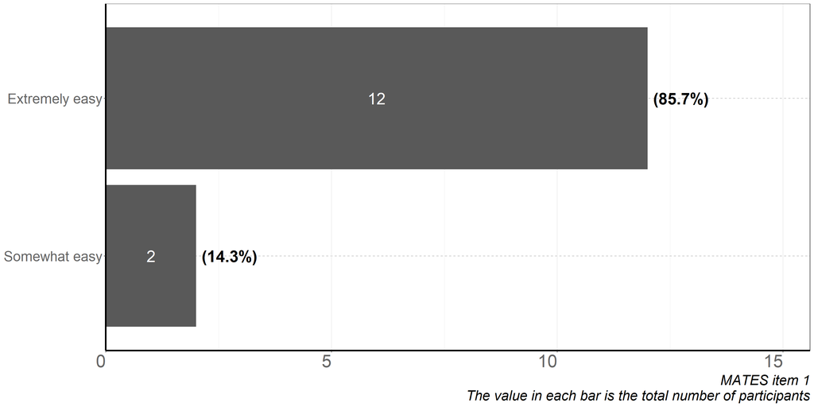

```r
# Separate rows and count total for Task Question 5 (Software Reporting Difficulty)
software_difficulty_count <- dat_task %>%
  filter(!is.na(Q3)) %>%
  count(Q3) %>%
  arrange(desc(n))

# Calculate count as a percentage
software_difficulty_percentage <-  software_difficulty_count %>%
  mutate(proportion = n/sum(software_difficulty_count$n),
         percentage = proportion*100)

# Plot for survey question 36
fig_task_Q3 <-  software_difficulty_count %>%
  ggplot(aes(x = n, y = reorder(Q3, n)), hjust = 0.5) +
  geom_bar(stat = "identity") +
  geom_text(aes(label = n, x = n/2 , y = reorder(Q3, n)), hjust = 0.5, size = 8, color = "white") +
 geom_text(data = software_difficulty_percentage, aes(label = paste0("(", round(percentage, 1), "%)"), x = n),
            hjust = -0.1, size = 8, color = "black", fontface = "bold") +
  scale_fill_identity(guide = "none") +
  scale_x_continuous(expand = c(0,0), limits = c(0, max(software_difficulty_count$n*1.3))) +
  MATES_theme() +
  labs(caption = "MATES item 1\nThe value in each bar is the total number of participants")

fig_task_Q3
```

```r
# ggsave(here("task_results", "fig_task_Q3.jpg"),  width = 16, height = 8, units = "cm", scale = 2, dpi = 120 )
```

## Question 4

Provide feedback and suggest rewording of the following item (if necessary):

Referring to MATES item 2:

**MATES item 2: Code reporting**

Question

o Do the authors report any relevant code used to conduct the analysis (i.e., the code used to conduct the computations, statistical models, and inferences comprising the meta-analysis) in the manuscript, supplementary material, or external repository?

Criteria for ‘Yes’

o The authors have reported any relevant code used to conduct the analysis in the manuscript, supplementary material, or external repository.

Criteria for ‘No’

o The authors have not reported any relevant code used to conduct the analysis in the manuscript, supplementary material, or external repository.

Criteria for ‘Not Applicable’

o The authors have used a GUI/click based software that does not produce a code or syntax. Alternatively, the authors have not reported the software used to conduct the analysis (i.e., ‘No’ to MATES item 1).

```r
# Filter for task question 4
dat_task_Q4 <- dat_task %>%
  select(c(Q5,Q4))

# Table for task question 4
 kable(dat_task_Q4, "html") %>%
    kable_styling("bordered", position = "left") %>%
    scroll_box(width = "150%", height = "400px")
```

Q5

Q4

Somewhat difficult

some of the GUI/click based software that does not produce a code per se but can produce the exact log of all procedures which can be used to recreate the analyses. In this case it would make sense to score as “yes”. However, if you are not familiar wth siftware it might be hard to tell whether it produces a log.

NA

NA

Extremely easy

NA

Extremely easy

NA

Somewhat easy

- The information provided in the glossary - definition of the graphical user interface (GUI) - was essential in order to be able to respond correctly if software such as Stata was used.
- What if the code is only partially reported?

Extremely easy

NA

Somewhat easy

It might be helpful to specify which common GUI software does (Stata, SPSS) and does not (Comprehensive Meta-Analysis Software) produce syntax or a coding log that can be reported. This distinction was mostly clear to me after reading the MATES checklist and glossary, so perhaps some of that text could be included for the ‘Not Applicable’ category.

Extremely easy

I don’t agree with the NA. Code is either there or not, and for full transparency it should be. Using a GUI does not mitigate that lack of transparency.

Somewhat difficult

This was difficult to apply to studies which used a GUI which could provide a syntax or coding log but this has not been reported in the manuscript or SI. E.g where a study has used Stata and has not provided a syntax/coding log. In these instances I answered ‘No’ but I was unsure whether this should be ‘not applicable’ as it us a GUI software rather than raw coding software

Extremely easy

NA

Somewhat easy

I used the keywords like “coding”, “code”, “programming” to search the answer. However, it seems that most papers did not display the code.

Somewhat easy

It may be hard for some people to decide between “No” and “NA”, because it requires knowledge on which software uses code vs. point-and-click.

Somewhat easy

Good question to evaluate the transparency and reproducibility of studies. But very rarely done.

Neither easy nor difficult

I sometimes struggle to decide between ‘No’ and ‘Not Applicable’. While I am familiar with some statistical languages and software, I cannot distinguish if unfamiliar programs are code-based or GUI/click-based.

Somewhat difficult

NA

```r
# write_csv(dat_task_Q4, file = here("task_results", "dat_task_Q4.csv"))
```

## Question 5

How difficult was MATES item 2: Code reporting to implement?

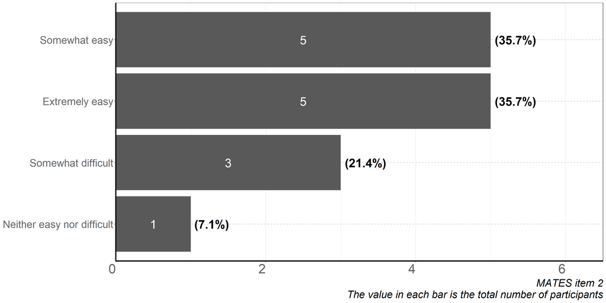

```r
# Separate rows and count total for Task Question 5 (Code Reporting Difficulty)
code_difficulty_count <- dat_task %>%
  filter(!is.na(Q5)) %>%
  count(Q5) %>%
  arrange(desc(n))

# Calculate count as a percentage
code_difficulty_percentage <-  code_difficulty_count %>%
  mutate(proportion = n/sum(code_difficulty_count$n),
         percentage = proportion*100)

# Plot for survey question 5
fig_task_Q5 <-  code_difficulty_count %>%
  ggplot(aes(x = n, y = reorder(Q5, n)), hjust = 0.5) +
  geom_bar(stat = "identity") +
  geom_text(aes(label = n, x = n/2 , y = reorder(Q5, n)), hjust = 0.5, size = 8, color = "white") +
  geom_text(data = code_difficulty_percentage, aes(label = paste0("(", round(percentage, 1), "%)"), x = n),
            hjust = -0.1, size = 8, color = "black", fontface = "bold") +
  scale_fill_identity(guide = "none") +
  scale_x_continuous(expand = c(0,0), limits = c(0, max(code_difficulty_count$n*1.3))) +
  MATES_theme() +
  labs(caption = "MATES item 2\nThe value in each bar is the total number of participants")

fig_task_Q5
```

```r
# ggsave(here("task_results", "fig_task_Q5.jpg"),  width = 16, height = 8, units = "cm", scale = 2, dpi = 120)
```

## Question 6

Provide feedback and suggest rewording of the following item (if necessary):

Referring to MATES item 3:

**MATES item 3: Number of included primary studies reporting**

Question

o Do the authors report the total number of primary studies (i.e., separate individual articles) included in the meta-analysis in the manuscript or supplementary material?

Criteria for ‘Yes’

o The authors have reported the total number of primary studies synthesised in the meta-analysis in the manuscript or supplementary material. The total number of studies can be inferred from a screening flowchart (e.g., PRISMA flowchart), or the authors can state the number of studies per subgroup analysis.

Criteria for ‘No’

o The authors have not reported the total number of primary studies synthesised in the meta-analysis in the manuscript or supplementary material. The total number of studies cannot be inferred by counting from a forest plot, or from a provided dataset.

Criteria for ‘Not Applicable’

o There is no ‘Not Applicable’ option for MATES item 3.

```r
# Filter for task question 6
dat_task_Q6 <- dat_task %>%
  select(c(Q7,Q6))

# Table for table question 6
 kable(dat_task_Q6, "html") %>%
    kable_styling("bordered", position = "left") %>%
    scroll_box(width = "150%", height = "400px")
```

| Q7 | Q6 |
| --- | --- |
| Somewhat easy | the word “studies” is often used with different meanings - e.g. sometimes is number of articles, but sometimes experiments or even effect sizes, which makes it tricky. Maybe clarify what you mean by “… |
| NA | NA |
| Extremely easy | NA |
| Extremely easy | NA |
| Extremely easy | NA |
| Extremely easy | NA |
| Extremely easy | NA |
| Extremely easy | NA |
| Extremely easy | Potentially this should also include a reference list of the included studies in the Supplementary material as it is useful to know which studies as well as how many |
| Extremely easy | NA |
| Somewhat easy | NA |
| Somewhat easy | NA |
| Extremely easy | In my opinion, it’s not a very discriminative question. For reproducibility, what is important, in my view, is the list of rejected studies along with the criteria |
| Somewhat easy | NA |
| Extremely easy | NA |

```r
# write_csv(dat_task_Q6, file = here("task_results", "dat_task_Q6.csv"))
```

## Question 7

How difficult was MATES item 3: Number of included primary studies reporting to implement?

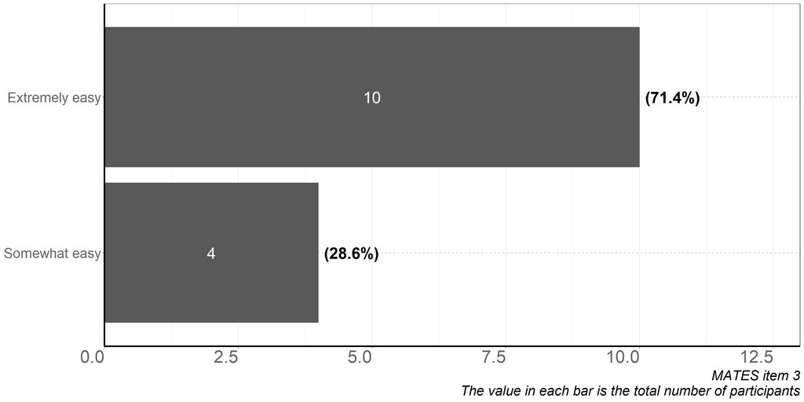

```r
# Separate rows and count total for Task Question 6 (Number of Included Studies Reporting Difficulty)
study_difficulty_count <- dat_task %>%
  filter(!is.na(Q7)) %>%
  count(Q7) %>%
  arrange(desc(n))

# Calculate count as a percentage
study_difficulty_percentage <- study_difficulty_count %>%
  mutate(proportion = n/sum(study_difficulty_count$n),
         percentage = proportion*100)

# Plot for survey question 7
fig_task_Q7 <- study_difficulty_count %>%
  ggplot(aes(x = n, y = reorder(Q7, n)), hjust = 0.5) +
  geom_bar(stat = "identity") +
  geom_text(aes(label = n, x = n/2 , y = reorder(Q7, n)), hjust = 0.5, size = 8, color = "white") +
  geom_text(data = study_difficulty_percentage, aes(label = paste0("(", round(percentage, 1), "%)"), x = n),
            hjust = -0.1, size = 8, color = "black", fontface = "bold") +
  scale_fill_identity(guide = "none") +
  scale_x_continuous(expand = c(0,0), limits = c(0, max(study_difficulty_count$n*1.3))) +
  MATES_theme() +
  labs(caption = "MATES item 3\nThe value in each bar is the total number of participants")

fig_task_Q7
```

```r
# ggsave(here("task_results", "fig_task_Q7.jpg"),  width = 16, height = 8, units = "cm", scale = 2, dpi = 120)
```

## Question 8

Provide feedback and suggest rewording of the following item (if necessary):

Referring to MATES item 4:

**MATES item 4: Number of included effect sizes reporting**

Question

o Do the authors report the total number of effect size estimates synthesised in the meta-analysis in the manuscript or supplementary material?

Criteria for ‘Yes’

o The authors have reported the total number of effect sizes estimates synthesised in the meta-analysis in the manuscript or supplementary material. The total number of effect sizes cannot be inferred by counting and must be stated explicitly.

Criteria for ‘No’

o The authors have not reported the total number of effect sizes synthesised in the meta-analysis in the manuscript or supplementary material. The total number of effect sizes cannot be inferred by counting and must be stated explicitly.

Criteria for ‘Not Applicable’

o There is no ‘Not Applicable’ option for MATES item 4.

```r
# Filter for task question 8
dat_task_Q8 <- dat_task %>%
  select(c(Q9,Q8))

# Table for task question 6
 kable(dat_task_Q6, "html") %>%
    kable_styling("bordered", position = "left") %>%
    scroll_box(width = "150%", height = "400px")
```

[output not shown]

```r
# write_csv(dat_task_Q8, file = here("task_results", "dat_task_Q8.csv"))
```

## Question 9

How difficult was MATES item 4: Number of included effect size reporting to implement?

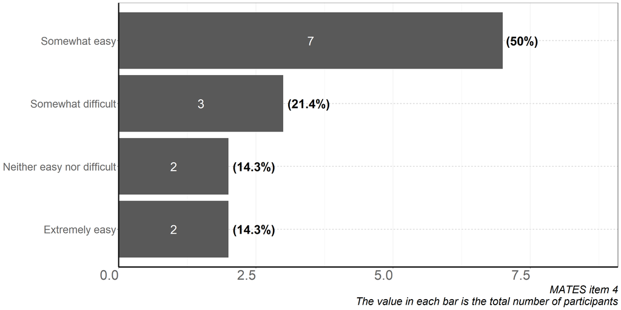

```r
# Separate rows and count total for Task Question 6 (Number of Included Studies Reporting Difficulty)
effectsize_difficulty_count <- dat_task %>%
  filter(!is.na(Q9)) %>%
  count(Q9) %>%
  arrange(desc(n))

# Calculate count as a percentage
effectsize_difficulty_percentage <- effectsize_difficulty_count %>%
  mutate(proportion = n/sum(effectsize_difficulty_count$n),
         percentage = proportion*100)

# Plot for survey question 6
fig_task_Q9 <- effectsize_difficulty_count %>%
  ggplot(aes(x = n, y = reorder(Q9, n)), hjust = 0.5) +
  geom_bar(stat = "identity") +
  geom_text(aes(label = n, x = n/2 , y = reorder(Q9, n)), hjust = 0.5, size = 8, color = "white") +
  geom_text(data = effectsize_difficulty_percentage, aes(label = paste0("(", round(percentage, 1), "%)"), x = n),
            hjust = -0.1, size = 8, color = "black", fontface = "bold") +
  scale_fill_identity(guide = "none") +
  scale_x_continuous(expand = c(0,0), limits = c(0, max(effectsize_difficulty_count$n*1.3))) +
  MATES_theme() +
  labs(caption = "MATES item 4\nThe value in each bar is the total number of participants")

fig_task_Q9
```

```r
# ggsave(here("survey_results", "fig_task_Q9.jpg"),  width = 16, height = 10, units = "cm", scale = 2, dpi = 120)
```

## Question 10

Provide feedback and suggest rewording of the following item (if necessary):

Referring to MATES item 5:

**MATES item 5: Effect size statistic formula reporting**

Question

o Do the authors report the formula (or reference for formula) for the effect size statistic/measure used (e.g., Zr, Hedge’s g, Cohen’s d, or lnRR) in the manuscript or supplementary material?

Criteria for ‘Yes’

o The authors have reported the formula (or reference for formula) for the effect size statistic/measure used in the manuscript or supplementary material.

Criteria for ‘No’

o The authors have not reported the formula (or reference for formula) for the effect size statistic/measure used in the manuscript or supplementary material.

Criteria for ‘Not Applicable’

o There is no ‘Not Applicable’ option for MATES item 5.

```r
# Filter for task question 10
dat_task_Q10 <- dat_task %>%
  select(c(Q11,Q10))

# Table for task question 10
 kable(dat_task_Q10, "html") %>%
    kable_styling("bordered", position = "left") %>%
    scroll_box(width = "150%", height = "400px")
```

| Q11 | Q10 |
| --- | --- |
| Somewhat easy | NA |
| NA | NA |
| Somewhat easy | Some may use correlations or percentages etc where a formula isn’t necessarily required |
| Extremely easy | NA |
| Extremely easy | NA |
| Neither easy nor difficult | It was often hard to find this information. |
| Extremely easy | NA |
| Extremely easy | NA |
| Somewhat easy | NA |
| Somewhat easy | NA |
| Somewhat easy | Most information can be obtained in the methodology part. However, sometimes the authors did not provide the formula for the effect size reporting. |
| Somewhat difficult | Some studies would extract means of a given variable (arm-based meta-analysis), or effect sizes that were already calculated in primary studies. In the former, there is no formula needed and it is not… |
| Neither easy nor difficult | Do we systematically need a formula when synthesizing information extracted directly from primary studies (i.e., when the authors have not done any recalculations or other modifications)? |
| Neither easy nor difficult | NA |
| Somewhat easy | NA |

```r
# write_csv(dat_task_Q10, file = here("task_results", "dat_task_Q10.csv"))
```

## Question 11

How difficult was MATES item 5: Effect size statistic/measure reporting to implement?

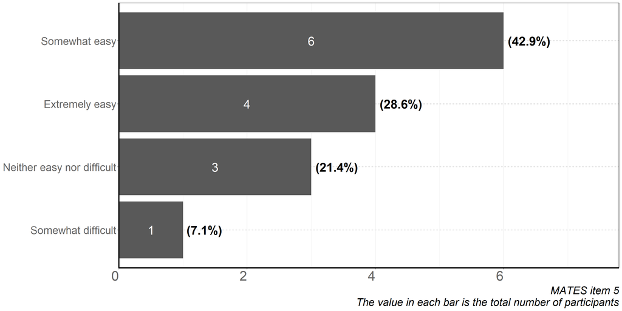

```r
# Separate rows and count total for Task Question 11 (Effect Size Statistic/Measure Reporting Difficulty)
effectsize_formula_difficulty_count <- dat_task %>%
  filter(!is.na(Q11)) %>%
  count(Q11) %>%
  arrange(desc(n))

# Calculate count as a percentage
effectsize_formula_difficulty_percentage <- effectsize_formula_difficulty_count %>%
  mutate(proportion = n/sum(effectsize_formula_difficulty_count$n),
         percentage = proportion*100)

# Plot for survey question 11
fig_task_Q11 <- effectsize_formula_difficulty_count %>%
  ggplot(aes(x = n, y = reorder(Q11, n)), hjust = 0.5) +
  geom_bar(stat = "identity") +
  geom_text(aes(label = n, x = n/2 , y = reorder(Q11, n)), hjust = 0.5, size = 8, color = "white") +
  geom_text(data = effectsize_formula_difficulty_percentage, aes(label = paste0("(", round(percentage, 1), "%)"), x = n),
            hjust = -0.1, size = 8, color = "black", fontface = "bold") +
  scale_fill_identity(guide = "none") +
  scale_x_continuous(expand = c(0,0), limits = c(0, max(effectsize_formula_difficulty_count$n*1.3))) +
  MATES_theme() +
  labs(caption = "MATES item 5\nThe value in each bar is the total number of participants")

fig_task_Q11
```

```r
# ggsave(here("task_results", "fig_task_Q11.jpg"),  width = 16, height = 8, units = "cm", scale = 2, dpi = 120)
```

## Question 12

Provide feedback and suggest rewording of the following item (if necessary):

Referring to MATES item 6:

**MATES item 6: Model type reporting**

Question

o Do the authors report the type of the meta-analytic/meta-regression model (e.g., fixed, random, or multi-level models), either descriptively or in statistical notation in the manuscript or supplementary material?

Criteria for ‘Yes’

o The authors have reported the type of the meta-analytic/meta-regression model, either descriptively or in statistical notation in the manuscript or supplementary material.

Criteria for ‘No’

o The authors have not reported the type of the meta-analytic/meta-regression model, either descriptively or in statistical notation in the manuscript or supplementary material.

Criteria for ‘Not Applicable’

o There is no ‘Not Applicable’ option for MATES item 6.

```r
# Filter for task question 12
dat_task_Q12 <- dat_task %>%
  select(c(Q13,Q12))

# Table for task question 12
 kable(dat_task_Q12, "html") %>%
    kable_styling("bordered", position = "left") %>%
    scroll_box(width = "150%", height = "400px")
```

| Q13 | Q12 |
| --- | --- |
| Somewhat easy | Unclear what you mean by “structure” - may need to explain that this means more than just stating that it was “random” or “fixed”? |
| NA | NA |
| Extremely easy | NA |
| Extremely easy | NA |
| Extremely easy | To be able to answer yes, does the model have to be specified (for example, in case of a random model how is the random part structured?) or is simply mentioning the type of model (fixed, random, …) s… |
| Somewhat difficult | Similar to #5, it was often hard to find this information. |
| Somewhat easy | The studies I reviewed varied widely in terms of the amount of detail provided for this item. I eventually decided to say ‘Yes’ if authors provide ANY mention of this, even if it is sometimes just a s… |
| Somewhat easy | NA |
| Somewhat easy | NA |
| Somewhat easy | NA |
| Somewhat easy | Keywords like fixed, random, or multi-level model are used to search. |
| Somewhat easy | The authors almost always report the type of model they use, but the details of the model specifications are often unclear. For instance, some authors would state that they used a “random-effect model… |
| Neither easy nor difficult | See my previous remark. Saying that a random-effects model was used is not enough in my opinion; more details are needed (especially about the structure of the random model, etc.) |
| Neither easy nor difficult | NA |
| Somewhat easy | NA |

```r
# write_csv(dat_task_Q12, file = here("task_results", "dat_task_Q12.csv"))
```

## Question 13

How difficult was MATES item 6: Model type reporting to implement?

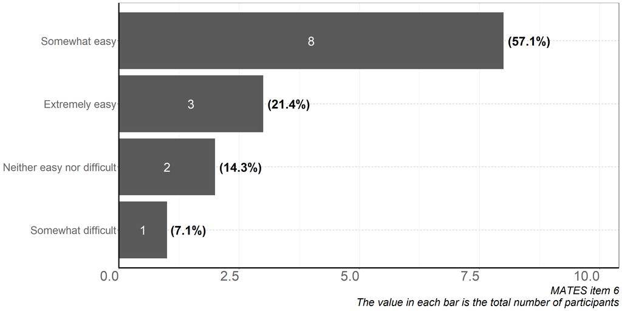

```r
# Separate rows and count total for Task Question 13 (Model Type Reporting Difficulty)
model_type_difficulty_count <- dat_task %>%
  filter(!is.na(Q13)) %>%
  count(Q13) %>%
  arrange(desc(n))

# Calculate count as a percentage
model_type_difficulty_percentage <- model_type_difficulty_count %>%
  mutate(proportion = n/sum(model_type_difficulty_count$n),
         percentage = proportion*100)

# Plot for survey question 13
fig_task_Q13 <- model_type_difficulty_count %>%
  ggplot(aes(x = n, y = reorder(Q13, n)), hjust = 0.5) +
  geom_bar(stat = "identity") +
  geom_text(aes(label = n, x = n/2 , y = reorder(Q13, n)), hjust = 0.5, size = 8, color = "white") +
  geom_text(data = model_type_difficulty_percentage, aes(label = paste0("(", round(percentage, 1), "%)"), x = n),
            hjust = -0.1, size = 8, color = "black", fontface = "bold") +
  scale_fill_identity(guide = "none") +
  scale_x_continuous(expand = c(0,0), limits = c(0, max(model_type_difficulty_count$n*1.3))) +
  MATES_theme() +
  labs(caption = "MATES item 6\nThe value in each bar is the total number of participants")

fig_task_Q13
```

```r
# ggsave(here("task_results", "fig_task_Q13.jpg"),  width = 16, height = 8, units = "cm", scale = 2, dpi = 120)
```

## Question 14

Provide feedback and suggest rewording of the following item (if necessary):

Referring to MATES item 7:

**MATES item 7: Effect size weights reporting**

Question

o Do the authors report the sampling variance, sampling error or equivalent (i.e., strategy to assign weights) of effect size estimates in the manuscript or supplementary material?

Criteria for ‘Yes’

o The authors have reported the sampling variance, sampling error or equivalent of effect size estimates in the manuscript or supplementary material.

Criteria for ‘No’

o The authors have not reported the sampling variance, sampling error or equivalent of effect size estimates in the manuscript or supplementary material.

Criteria for ‘Not Applicable’

o The authors have conducted a meta-analysis without weights (i.e., unweighted meta-analysis).

```r
# Filter for task question 14
dat_task_Q14 <- dat_task %>%
  select(c(Q15,Q14))

# Table for task question 14
 kable(dat_task_Q14, "html") %>%
    kable_styling("bordered", position = "left") %>%
    scroll_box(width = "150%", height = "400px")
```

| Q15 | Q14 |
| --- | --- |
| Somewhat easy | Change the order of wuation parts to make it clearer and align with other: “Do the authors report the strategy used to assign weights of effect size estimates (e.g. the sampling variance, sampling err… |
| NA | NA |
| Extremely easy | NA |
| Somewhat easy | NA |
| Somewhat easy | Perhaps you should specify that the values are expected, because the weights can be reported graphically by differences in point size. |
| Extremely difficult | This was quite confusing for me, especially the “No” versus “NA”. I really couldn’t tell the difference between these and when to select one over the other. |
| Somewhat easy | I assumed this item was looking for authors to say something like “we weighted effect sizes based on the inverse of their sampling variances”, rather than provide the actual weights in a data file. Ho… |
| Somewhat easy | NA |
| Extremely difficult | I found this criteria difficult to apply. This is either because none of the meta-analyses I reviewed reported the sampling variance, sampling error or equivalent, OR because I did not understand what… |
| Somewhat easy | I considered that 95%CI associated with effect sizes (reported in the text or shown in forest plots) would be a measure of weight |
| Somewhat easy | NA |
| Somewhat difficult | I was a bit confused about the wording of this item. It is quite common for authors to report the % of weights taken by each study in their analyses, but not how these weights were calculated, or even… |
| Neither easy nor difficult | The question may not be very clear. Do we want to know if and how the authors weighted the studies (and therefore that the text states this clearly), or do we want information on the precision of indi… |
| Neither easy nor difficult | Some papers seemed to be weighted in the results, although the authors did not explicitly state this |
| Somewhat easy | NA |

```r
# write_csv(dat_task_Q14, file = here("task_results", "dat_task_Q14.csv"))
```

## Question 15

How difficult was MATES item 7: Effect size weights reporting to implement?

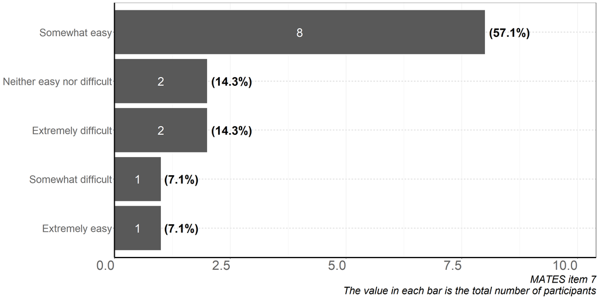

```r
# Separate rows and count total for Task Question 15 (Effect Size Weights Reporting Difficulty)
effect_size_weights_difficulty_count <- dat_task %>%
  filter(!is.na(Q15)) %>%
  count(Q15) %>%
  arrange(desc(n))

# Calculate count as a percentage
effect_size_weights_difficulty_percentage <- effect_size_weights_difficulty_count %>%
  mutate(proportion = n/sum(effect_size_weights_difficulty_count$n),
         percentage = proportion*100)

# Plot for survey question 15
fig_task_Q15 <- effect_size_weights_difficulty_count %>%
  ggplot(aes(x = n, y = reorder(Q15, n)), hjust = 0.5) +
  geom_bar(stat = "identity") +
  geom_text(aes(label = n, x = n/2 , y = reorder(Q15, n)), hjust = 0.5, size = 8, color = "white") +
  geom_text(data = effect_size_weights_difficulty_percentage, aes(label = paste0("(", round(percentage, 1), "%)"), x = n),
            hjust = -0.1, size = 8, color = "black", fontface = "bold") +
  scale_fill_identity(guide = "none") +
  scale_x_continuous(expand = c(0,0), limits = c(0, max(effect_size_weights_difficulty_count$n*1.3))) +
  MATES_theme() +
  labs(caption = "MATES item 7\nThe value in each bar is the total number of participants")

fig_task_Q15
```

```r
# ggsave(here("task_results", "fig_task_Q15.jpg"),  width = 16, height = 8, units = "cm", scale = 2, dpi = 120)
```

## Question 16

Provide feedback and suggest rewording of the following item (if necessary):

Referring to MATES item 8:

**MATES item 8: Effect size dependence (non-independence) reporting**

Question

o Do the authors report the dependence (e.g., multiplicity or, repeated measure) of effect size estimates (e.g., acknowledge multiple effect sizes were taken from a single study) in the manuscript or supplementary material?

Criteria for ‘Yes’

o The authors have reported whether there is dependence of effect size estimates in the manuscript or supplementary material. If a meta-analysis reports that effect size estimates are independent allocate ‘Yes’.

Criteria for ‘No’

o The authors have not reported whether there is dependence of effect size estimates in the manuscript or supplementary material.

Criteria for ‘Not Applicable’

o There is no ‘Not Applicable’ option for MATES item 8.

```r
# Filter for task question 16
dat_task_Q16 <- dat_task %>%
  select(c(Q17,Q16))

# Table for task question 16
 kable(dat_task_Q16, "html") %>%
    kable_styling("bordered", position = "left") %>%
    scroll_box(width = "150%", height = "400px")
```

| Q17 | Q16 |
| --- | --- |
| Somewhat easy | Sometimes they explicitly state they assume they are independent even they know they are not - not clear if this means that “If a meta-analysis reports that effect size estimates are independent” or n… |
| NA | NA |
| Extremely easy | NA |
| Extremely easy | NA |
| Somewhat easy | How to respond when independence is not explicitly stated but is obvious (because one effect size = one primary study)? |
| Extremely difficult | Authors don’t really seem to report this, so a lot of time is spent reading the paper and supplement trying to find out if this was done anywhere. |
| Somewhat difficult | This is the item I had the most trouble with, especially because I found it difficult to separate from the item about model structure/random effects. Most studies that I reviewed used a random effects… |
| Neither easy nor difficult | Are we only expecting this if there is a risk of non-dependency? A MA with say 6 studies with 6 author groups at 6 different times may not see the need to state this. |
| Extremely difficult | I found this criteria difficult to apply. Similarly to MATES Item 7, I am unsure whether this is because none of the meta-analyses I reviewed included the dependence of effect size estimates OR becaus… |
| Somewhat easy | I considered that a study would did not ‘report the dependence of effect size estimates’ when it did not state that explicitly in the text. However it is quite easy to see if there is dependency of ef… |
| Neither easy nor difficult | NA |
| Somewhat difficult | This was a tricky one too. If the authors used a random-effect model, then in almost all cases it is to account for the non-independence of effect sizes among studies, but the authors do not necessari… |
| Neither easy nor difficult | Good question, but should we evaluate the strategies used by the authors? Pooling, exclusion, … Some are recommended, others are not… |
| Neither easy nor difficult | NA |
| Somewhat easy | NA |

```r
# write_csv(dat_task_Q16, file = here("task_results", "dat_task_Q16.csv"))
```

## Question 17

How difficult was MATES item 8: Effect size dependence (non-independence) reporting to implement?

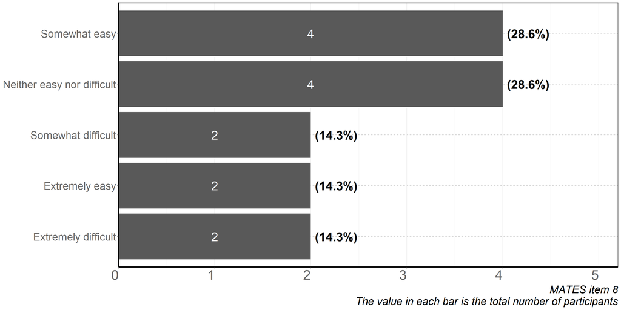

```r
# Separate rows and count total for Task Question 17 (Effect Size Dependence Reporting Difficulty)
effect_size_dependence_difficulty_count <- dat_task %>%
  filter(!is.na(Q17)) %>%
  count(Q17) %>%
  arrange(desc(n))

# Calculate count as a percentage
effect_size_dependence_difficulty_percentage <- effect_size_dependence_difficulty_count %>%
  mutate(proportion = n/sum(effect_size_dependence_difficulty_count$n),
         percentage = proportion*100)

# Plot for survey question 17
fig_task_Q17 <- effect_size_dependence_difficulty_count %>%
  ggplot(aes(x = n, y = reorder(Q17, n)), hjust = 0.5) +
  geom_bar(stat = "identity") +
  geom_text(aes(label = n, x = n/2 , y = reorder(Q17, n)), hjust = 0.5, size = 8, color = "white") +
  geom_text(data = effect_size_dependence_difficulty_percentage, aes(label = paste0("(", round(percentage, 1), "%)"), x = n),
            hjust = -0.1, size = 8, color = "black", fontface = "bold") +
  scale_fill_identity(guide = "none") +
  scale_x_continuous(expand = c(0,0), limits = c(0, max(effect_size_dependence_difficulty_count$n*1.3))) +
  MATES_theme() +
  labs(caption = "MATES item 8\nThe value in each bar is the total number of participants")

fig_task_Q17
```

```r
# ggsave(here("task_results", "fig_task_Q17.jpg"),  width = 16, height = 8, units = "cm", scale = 2, dpi = 120)
```

## Question 18

Provide feedback and suggest rewording of the following item (if necessary):

Referring to MATES item 9:

**MATES item 9: Overall mean effect reporting**

Question

o Do the authors report the overall mean effect of the meta-analyses/meta-regression using a plot, table or within text in the manuscript or supplementary material?

Criteria for ‘Yes’

o The authors reported the overall mean effect of the meta-analyses/meta-regression in the text, or within a plot or table in the manuscript or supplementary material.

Criteria for ‘No’

o The authors have not reported the overall mean effect of the meta-analyses/meta-regression in the text, or within a plot or table in the manuscript or supplementary material.

Criteria for ‘Not Applicable’

o There is no ‘Not Applicable’ option for MATES item 9.

```r
# Filter for task question 18
dat_task_Q18 <- dat_task %>%
  select(c(Q19,Q18))

# Table for task question 18
 kable(dat_task_Q18, "html") %>%
    kable_styling("bordered", position = "left") %>%
    scroll_box(width = "150%", height = "400px")
```

| Q19 | Q18 |
| --- | --- |
| Somewhat easy | NA |
| NA | NA |
| Somewhat difficult | Many studies don’t report a global mean but report means for a series of moderators or sub-analyses. It wasn’t clear if this would fall under the definition of “overall mean” as it might not make sens… |
| Extremely easy | NA |
| Extremely easy | NA |
| Extremely difficult | I was never quite sure what was considered “enough” to count as an overall mean effect size. Again, this didn’t seem to be done very often, so I had to make subjective judgement calls to implement thi… |
| Extremely easy | NA |
| Extremely easy | NA |
| Somewhat easy | NA |
| Somewhat easy | NA |
| Neither easy nor difficult | It can be checked via the tables/graphs produced by the authors. |
| Somewhat difficult | I found that many studies do not have an “overall effect”, because it is not necessarily relevant to their questions. Then it is really hard to determine what is an “overall mean-effect” for the “meta… |
| Extremely easy | Is it just going to be yeses? How do you present a meta-analysis without including the overall mean effect? |
| Neither easy nor difficult | NA |
| Extremely easy | NA |

```r
# write_csv(dat_task_Q18, file = here("task_results", "dat_task_Q18.csv"))
```

## Question 19

How difficult was MATES item 9: Overall mean effect reporting to implement?

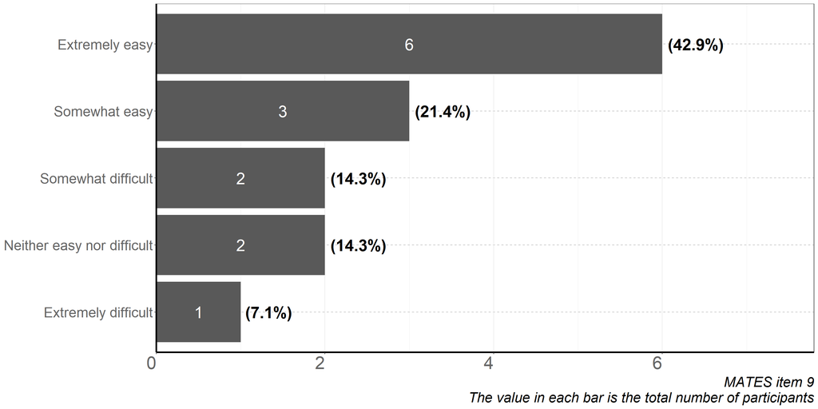

```r
# Separate rows and count total for Task Question 19 (Overall Mean Effect Reporting Difficulty)
mean_effect_difficulty_count <- dat_task %>%
  filter(!is.na(Q19)) %>%
  count(Q19) %>%
  arrange(desc(n))

# Calculate count as a percentage
mean_effect_difficulty_percentage <- mean_effect_difficulty_count %>%
  mutate(proportion = n/sum(mean_effect_difficulty_count$n),
         percentage = proportion*100)

# Plot for survey question 19
fig_task_Q19 <- mean_effect_difficulty_count %>%
  ggplot(aes(x = n, y = reorder(Q19, n)), hjust = 0.5) +
  geom_bar(stat = "identity") +
  geom_text(aes(label = n, x = n/2 , y = reorder(Q19, n)), hjust = 0.5, size = 8, color = "white") +
  geom_text(data = mean_effect_difficulty_percentage, aes(label = paste0("(", round(percentage, 1), "%)"), x = n),
            hjust = -0.1, size = 8, color = "black", fontface = "bold") +
  scale_fill_identity(guide = "none") +
  scale_x_continuous(expand = c(0,0), limits = c(0, max(mean_effect_difficulty_count$n*1.3))) +
  MATES_theme() +
  labs(caption = "MATES item 9\nThe value in each bar is the total number of participants")

fig_task_Q19
```

```r
# ggsave(here("task_results", "fig_task_Q19.jpg"),  width = 16, height = 8, units = "cm", scale = 2, dpi = 120)
```

## Question 20

Provide feedback and suggest rewording of the following item (if necessary):

Referring to MATES item 10:

**MATES item 10: Heterogeneity reporting**

Question

o Do the authors report an assessment of heterogeneity (e.g., I2, tau2, 𝜎 2 or, Q-statistic) between effect size estimates in the manuscript or supplementary material?

Criteria for ‘Yes’

o The authors have reported an assessment of heterogeneity between effect size estimates in the manuscript or supplementary material.

Criteria for ‘No’

o The authors have not reported an assessment of heterogeneity between effect size estimates in the manuscript or supplementary material.

Criteria for ‘Not Applicable’

o The study has stated that the analysis is unweighted.

```r
# Filter for task question 20
dat_task_Q20 <- dat_task %>%
  select(c(Q21,Q20))

# Table for task question 20
 kable(dat_task_Q20, "html") %>%
    kable_styling("bordered", position = "left") %>%
    scroll_box(width = "150%", height = "400px")
```

| Q21 | Q20 |
| --- | --- |
| Somewhat easy | NA |
| NA | NA |
| Extremely easy | NA |
| Extremely easy | NA |
| Somewhat easy | Can we answer yes if heterogeneity is assessed only during a subgroup analysis? |
| Somewhat easy | NA |
| Somewhat easy | One study I reviewed did not report heterogeneity statistics, but did test for the ‘significance’ of heterogeneity using Chi-squared tests and p-values. I did not consider that to be the same as repor… |
| Somewhat easy | NA |
| Somewhat easy | NA |
| Somewhat easy | NA |
| Somewhat easy | Keyword “heterogeneity” is used. |
| Somewhat easy | I found that authors sometimes mention that they assessed heterogeneity, but do not necessarily report the values of their heterogeneity assessment. What response should be used in this case? I also f… |
| Somewhat easy | NA |
| Somewhat easy | NA |
| Somewhat easy | NA |

```r
# write_csv(dat_task_Q20, file = here("task_results", "dat_task_Q20.csv"))
```

## Question 21

“How difficult was MATES item 10: Heterogeneity reporting to implement?”

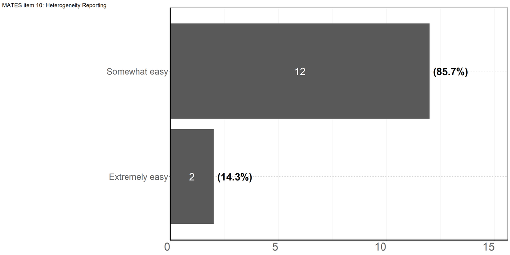

```r
# Separate rows and count total for Task Question 21 (Heterogeneity Reporting Difficulty)
heterogeneity_difficulty_count <- dat_task %>%
  filter(!is.na(Q21)) %>%
  count(Q21) %>%
  arrange(desc(n))

# Calculate count as a percentage
heterogeneity_difficulty_percentage <- heterogeneity_difficulty_count %>%
  mutate(proportion = n/sum(heterogeneity_difficulty_count$n),
         percentage = proportion*100)

# Plot for survey question 21
fig_task_Q21 <- heterogeneity_difficulty_count %>%
  ggplot(aes(x = n, y = reorder(Q21, n)), hjust = 0.5) +
  geom_bar(stat = "identity") +
  geom_text(aes(label = n, x = n/2 , y = reorder(Q21, n)), hjust = 0.5, size = 8, color = "white") +
  geom_text(data = heterogeneity_difficulty_percentage, aes(label = paste0("(", round(percentage, 1), "%)"), x = n),
            hjust = -0.1, size = 8, color = "black", fontface = "bold") +
  scale_fill_identity(guide = "none") +
  scale_x_continuous(expand = c(0,0), limits = c(0, max(heterogeneity_difficulty_count$n*1.3))) +
  MATES_theme() +
  labs(tag = "MATES item 10: Heterogeneity Reporting", size = 15)

fig_task_Q21
```

```r
# ggsave(here("task_results", "fig_task_Q21.jpg"),  width = 16, height = 8, units = "cm", scale = 2, dpi = 120)
```

## Question 22

Provide feedback and suggest rewording of the following item (if necessary):

Referring to MATES item 11:

**MATES item 11: Publication bias reporting**

Question

o Do the authors report an assessment of publication bias in the manuscript or supplementary material?

Criteria for ‘Yes’

o The authors have reported an assessment of publication bias in the manuscript or supplementary material.

Criteria for ‘No’

o The authors have not reported an assessment of publication bias in the manuscript or supplementary material.

Criteria for ‘Not Applicable’

o The authors report that an assessment of publication bias cannot be conducted.

```r
# Filter for task question 22
dat_task_Q22 <- dat_task %>%
  select(c(Q23,Q22))

# Table for task question 22
 kable(dat_task_Q22, "html") %>%
    kable_styling("bordered", position = "left") %>%
    scroll_box(width = "150%", height = "400px")
```

| Q23 | Q22 |
| --- | --- |
| Somewhat easy | NA |
| NA | NA |
| Somewhat easy | Some say that they just report ‘publication bias corrected models’ so they don’t necessarily report a measure of publication bias per se |
| Extremely easy | NA |
| Extremely easy | *Perhaps you could clarify that graphic-only assessments (without any tests) are also valid?* What should be done when authors justify that it is not possible to assess publication bias (because of a … |
| Extremely easy | NA |
| Extremely easy | NA |
| Somewhat easy | NA |
| Extremely easy | NA |
| Extremely easy | NA |
| Neither easy nor difficult | Publication bias is the keyword to be used. However, sometimes the authors tend to provide the results in the supplementary info. |
| Extremely easy | NA |
| Somewhat easy | Should we assess the quality of publication bias analysis? The fail-safe N number is not as powerful as Bayesian workflows that directly account for publication bias (ROBMA). |
| Somewhat easy | NA |
| Somewhat easy | NA |

```r
# write_csv(dat_task_Q22, file = here("task_results", "dat_task_Q22.csv"))
```

## Question 23

How difficult was MATES item 11: Publication bias reporting to implement?

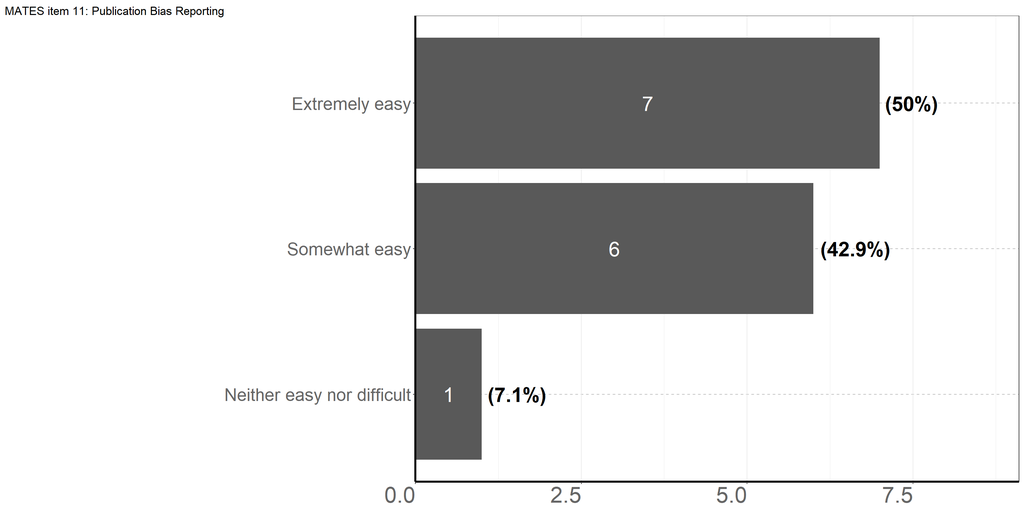

```r
# Separate rows and count total for Task Question 23 (Publication Bias Reporting Difficulty)
publication_bias_difficulty_count <- dat_task %>%
  filter(!is.na(Q23)) %>%
  count(Q23) %>%
  arrange(desc(n))

# Calculate count as a percentage
publication_bias_difficulty_percentage <- publication_bias_difficulty_count %>%
  mutate(proportion = n/sum(publication_bias_difficulty_count$n),
         percentage = proportion*100)

# Plot for survey question 23
fig_task_Q23 <- publication_bias_difficulty_count %>%
  ggplot(aes(x = n, y = reorder(Q23, n)), hjust = 0.5) +
  geom_bar(stat = "identity") +
  geom_text(aes(label = n, x = n/2 , y = reorder(Q23, n)), hjust = 0.5, size = 8, color = "white") +
  geom_text(data = publication_bias_difficulty_percentage, aes(label = paste0("(", round(percentage, 1), "%)"), x = n),
            hjust = -0.1, size = 8, color = "black", fontface = "bold") +
  scale_fill_identity(guide = "none") +
  scale_x_continuous(expand = c(0,0), limits = c(0, max(publication_bias_difficulty_count$n*1.3))) +
  MATES_theme() +
  labs(tag = "MATES item 11: Publication Bias Reporting", size = 15)

fig_task_Q23
```

```r
# ggsave(here("task_results", "fig_task_Q23.jpg"),  width = 16, height = 8, units = "cm", scale = 2, dpi = 120)
```

## Question 24

Provide feedback and suggest rewording of the following item (if necessary):

Referring to MATES item 12:

**MATES item 12: Sensitivity analysis reporting**

Question

o Do the authors report a sensitivity analysis or subset analysis in addition to the publication bias assessment (e.g., leave-one-out analysis, use of alternative model or within-study risk of bias assessment) in the manuscript or supplementary material?

Criteria for ‘Yes’

o The authors reported a sensitivity analysis in addition to the publication bias assessment in the manuscript or supplementary material.

Criteria for ‘No’

o The authors have not reported a sensitivity analysis in addition to the publication bias assessment in the manuscript or supplementary material.

Criteria for ‘Not Applicable’

o There is no ‘Not Applicable’ option for MATES item 12.

```r
# Filter for task question 24
dat_task_Q24 <- dat_task %>%
  select(c(Q25,Q24))

# Table for task question 24
 kable(dat_task_Q24, "html") %>%
    kable_styling("bordered", position = "left") %>%
    scroll_box(width = "150%", height = "400px")
```

Q25

Q24

Neither easy nor difficult

Unclear if any subgroup analysis can be considered sensitivity analysis - often it actyually is the main analysis

NA

NA

Somewhat easy

One study stated that it did sub-analyses as a form of sensitivity. Many studies do sub-analyses but don’t call it a sensitivity analysis. Would this fall under “use of alternative model”?

Extremely easy

NA

Somewhat easy

- In the question, what exactly do you mean by “within-study risk of bias assessment”?
- If risk of bias levels of each studies are provided but the risk of bias assessment is not used in the meta-analysis, what should be done?
- Can Cook’s distance calculations or other outlier and influential case diagnostics be considered as a sensitivity analysis?
- What should be done when the authors say they have carried out a sensitivity analysis but neither the method nor the results are reported?

Extremely easy

NA

Somewhat easy

In my mind, sensitivity analysis is not the same as a subgroup analysis but I noticed the latter were much more common in the studies I reviewed. Perhaps make it clearer that both are acceptable, despite being different?

Somewhat easy

NA

Extremely easy

NA

Somewhat easy

NA

Neither easy nor difficult

Some sensitivity analyses are provided in the supplementary materials. Sometimes need to check the figures/tables drawn by the authors to identify whether sensitivity analysis is conducted.

Somewhat easy

NA

Neither easy nor difficult

There are many possible types of sensitivity analyses. Should we specify or clarify which one is being used?

Neither easy nor difficult

NA

Somewhat easy

NA

```r
# write_csv(dat_task_Q24, file = here("task_results", "dat_task_Q24.csv"))
```

## Question 25

How difficult was MATES item 12: Sensitivity analysis reporting to implement?

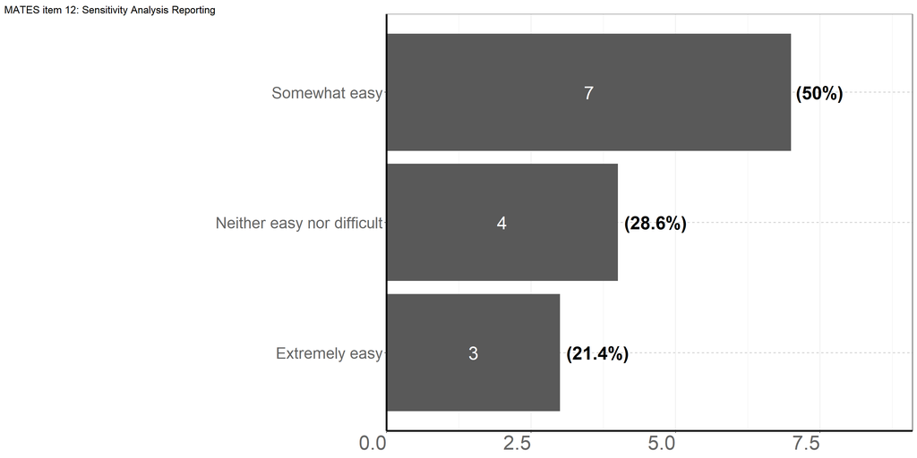

```r
# Separate rows and count total for Task Question 25 (Sensitivity Analysis Reporting Difficulty)
sensitivity_analysis_difficulty_count <- dat_task %>%
  filter(!is.na(Q25)) %>%
  count(Q25) %>%
  arrange(desc(n))

# Calculate count as a percentage
sensitivity_analysis_difficulty_percentage <- sensitivity_analysis_difficulty_count %>%
  mutate(proportion = n/sum(sensitivity_analysis_difficulty_count$n),
         percentage = proportion*100)

# Plot for survey question 25
fig_task_Q25 <- sensitivity_analysis_difficulty_count %>%
  ggplot(aes(x = n, y = reorder(Q25, n)), hjust = 0.5) +
  geom_bar(stat = "identity") +
  geom_text(aes(label = n, x = n/2 , y = reorder(Q25, n)), hjust = 0.5, size = 8, color = "white") +
  geom_text(data = sensitivity_analysis_difficulty_percentage, aes(label = paste0("(", round(percentage, 1), "%)"), x = n),
            hjust = -0.1, size = 8, color = "black", fontface = "bold") +
  scale_fill_identity(guide = "none") +
  scale_x_continuous(expand = c(0,0), limits = c(0, max(sensitivity_analysis_difficulty_count$n*1.3))) +
  MATES_theme() +
  labs(tag = "MATES item 12: Sensitivity Analysis Reporting", size = 15)

fig_task_Q25
```

```r
# ggsave(here("task_results", "fig_task_Q25.jpg"),  width = 16, height = 8, units = "cm", scale = 2, dpi = 120)
```

## Question 26

Provide feedback and suggest rewording of the following item (if necessary):

Referring to MATES item 13:

**MATES item 13: Data reporting/archiving**

Question

o Do the authors report the data (i.e., used to calculate effect sizes and conduct the meta-analysis) extracted from each eligible primary study (i.e., research paper) in the manuscript, supplementary material, or external repository?

Criteria for ‘Yes’

o The authors have reported the data extracted from each eligible primary in the manuscript, supplementary material, or external repository. In cases when the authors state the data is sensitive and cannot be shared allocate ‘Yes’.

Criteria for ‘No’

o The authors have not reported the data extracted from each eligible primary study the manuscript, supplementary material, or external repository.

Criteria for ‘Not Applicable’

o There is no ‘Not Applicable’ option for MATES item 13.

```r
# Filter for task question 26
dat_task_Q26 <- dat_task %>%
  select(c(Q27,Q26))

# Table for task question 26
 kable(dat_task_Q26, "html") %>%
    kable_styling("bordered", position = "left") %>%
    scroll_box(width = "150%", height = "400px")
```

Q27

Q26

Somewhat easy

NA

NA

NA

Somewhat easy

What about studies that say to contact author/available upon request?

Somewhat easy

NA

Somewhat easy

- What should be done if the data has been only partially reported?
- I would suggest to detail in the question “Do the authors report the data (i.e. extracted data used to calculate effect sizes, calculated/transformed data used to conduct the meta-analysis (effect size estimate, variance))”

Extremely easy

NA

Extremely easy

NA

Somewhat easy

NA

Neither easy nor difficult

There is a typo in the ‘Criteria for ’Yes’’ Section. ‘The authors have reported the data extracted from each eligible primary **study?** in the manuscript……’ Mostly this criteria was easy to apply but it was not always obvious which data were used to calculate the effect sizes and conduct the meta-analysis, therefore it was not always obvious whether these had been included in the tables.

Extremely easy

NA

Somewhat difficult

The phrase “report the data” is a bit vague. Does it mean the authors have to provide the raw data or shall we tick “yes” if the authors have listed what kind of data is included?

Somewhat easy

I think it’s worth noting that the data availability statement is sometimes only displayed in the online html version (not in the PDF). Also, what is referred to as “the data” needs to be more strictly defined as “raw data”. It is very common for authors to present some data, or the data with the calculated effect sizes, but not the RAW data that was used to calculate the effect sizes.

Neither easy nor difficult

I often find this information in forest plots, does it count?

Neither easy nor difficult

NA

Somewhat difficult

NA

```r
# write_csv(dat_task_Q26, file = here("task_results", "dat_task_Q26.csv"))
```

## Question 27

How difficult was MATES item 13: Data reporting/archiving to implement?

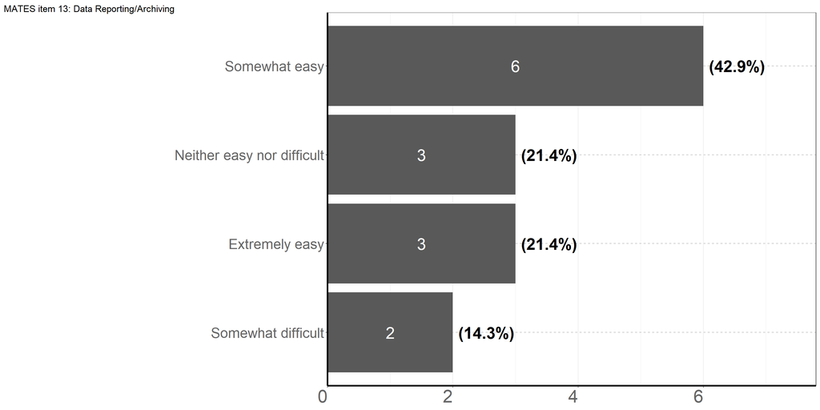

```r
# Separate rows and count total for Task Question 27 (Data Reporting/Archiving Difficulty)
data_archiving_difficulty_count <- dat_task %>%
  filter(!is.na(Q27)) %>%
  count(Q27) %>%
  arrange(desc(n))

# Calculate count as a percentage
data_archiving_difficulty_percentage <- data_archiving_difficulty_count %>%
  mutate(proportion = n/sum(data_archiving_difficulty_count$n),
         percentage = proportion*100)

# Plot for survey question 27
fig_task_Q27 <- data_archiving_difficulty_count %>%
  ggplot(aes(x = n, y = reorder(Q27, n)), hjust = 0.5) +
  geom_bar(stat = "identity") +
  geom_text(aes(label = n, x = n/2 , y = reorder(Q27, n)), hjust = 0.5, size = 8, color = "white") +
  geom_text(data = data_archiving_difficulty_percentage, aes(label = paste0("(", round(percentage, 1), "%)"), x = n),
            hjust = -0.1, size = 8, color = "black", fontface = "bold") +
  scale_fill_identity(guide = "none") +
  scale_x_continuous(expand = c(0,0), limits = c(0, max(data_archiving_difficulty_count$n*1.3))) +
  MATES_theme() +
  labs(tag = "MATES item 13: Data Reporting/Archiving", size = 15)

fig_task_Q27
```

```r
# ggsave(here("task_results", "fig_task_Q27.jpg"),  width = 16, height = 8, units = "cm", scale = 2, dpi = 120)
```

## Question 28

Provide feedback and suggest rewording of the following item (if necessary):

Referring to MATES item 14:

**MATES item 14: Variable description reporting/archiving**

Question

o Do the authors report descriptions of the variables extracted (i.e., meta-data or columns in dataset) from each eligible study primary study (i.e., research paper) in the manuscript, supplementary material, or external repository?

Criteria for ‘Yes’

o The authors have reported descriptions of the variables extracted from each eligible study primary study in the manuscript, supplementary material, or external repository.

Criteria for ‘No’

o The authors have not reported descriptions of the variables extracted from each eligible study primary study in the manuscript, supplementary material, or external repository.

Criteria for ‘Not Applicable’

o The authors have not reported the data extracted from each eligible primary study in the manuscript, supplementary material, or external repository (i.e., ‘No’ for MATES item 13) or the authors have reported that the data cannot be provided because the data is sensitive.

```r
# Filter for task question 28
dat_task_Q28 <- dat_task %>%
  select(c(Q29,Q28))

# Table for task question 28
 kable(dat_task_Q28, "html") %>%
    kable_styling("bordered", position = "left") %>%
    scroll_box(width = "150%", height = "400px")
```

Q29

Q28

Somewhat easy

made mistake here a few times when the data was not reported selected “no” rather than “NA”. My foult not reading carefully!

NA

NA

Somewhat difficult

Many studies list the types of data extracted but don’t provide “descriptions” of the variables. The wording of this item was a bit confusing about what it was asking. Does it was explicit definitions or is a list of data items enough?

Somewhat easy

NA

Somewhat difficult

- What should be done in case of partially reported data?
- In the reporting of variables, I see two categories, variables that describe the scope of the meta-analysed literature (e.g. geography, year of publication) and variables that are used in the meta-analysis in subgroup analyses. The first category could be covered by item 14, but the second category would be covered by item 13 (‘data used to conduct the meta-analysis’). Items 13 and 14 could be merged (and the assessment would only concern the reporting of variables used in the meta-analysis) or these two categories of variables would have to be clarified in the description of the questions.

Neither easy nor difficult

I did have a case where they did this (item 14), but didn’t do item 13 (no data provided).

Extremely easy

NA

Neither easy nor difficult

NA

Somewhat easy

This was difficult to apply in instances where the data were not described explicitly as such but were clear from Table column headings or similar. In these instances I answered ‘Yes’ and commented in the justification box. Should a description of the variable also include a unit?

Somewhat easy

NA

Somewhat easy

NA

Somewhat easy

NA

Somewhat difficult

I’m not entirely sure I understood this question well. Should authors describe in the text the variables they are interested in? Should this description be exhaustive? Authors often mention some variables, but are they comprehensive? Or should we have access to them (e.g., in their database)?

Neither easy nor difficult

NA

Somewhat difficult

NA

```r
# write_csv(dat_task_Q28, file = here("task_results", "dat_task_Q28.csv"))
```

## Question 29

How difficult was MATES item 14: Variable description reporting to implement?

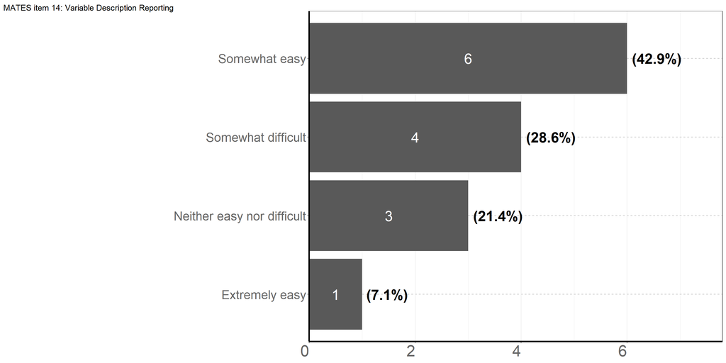

```r
# Separate rows and count total for Task Question 29 (Variable Description Reporting Difficulty)
variable_description_difficulty_count <- dat_task %>%
  filter(!is.na(Q29)) %>%
  count(Q29) %>%
  arrange(desc(n))

# Calculate count as a percentage
variable_description_difficulty_percentage <- variable_description_difficulty_count %>%
  mutate(proportion = n/sum(variable_description_difficulty_count$n),
         percentage = proportion*100)

# Plot for survey question 29
fig_task_Q29 <- variable_description_difficulty_count %>%
  ggplot(aes(x = n, y = reorder(Q29, n)), hjust = 0.5) +
  geom_bar(stat = "identity") +
  geom_text(aes(label = n, x = n/2 , y = reorder(Q29, n)), hjust = 0.5, size = 8, color = "white") +
  geom_text(data = variable_description_difficulty_percentage, aes(label = paste0("(", round(percentage, 1), "%)"), x = n),
            hjust = -0.1, size = 8, color = "black", fontface = "bold") +
  scale_fill_identity(guide = "none") +
  scale_x_continuous(expand = c(0,0), limits = c(0, max(variable_description_difficulty_count$n*1.3))) +
  MATES_theme() +
  labs(tag = "MATES item 14: Variable Description Reporting", size = 15)

fig_task_Q29
```

```r
# ggsave(here("task_results", "fig_task_Q29.jpg"),  width = 16, height = 8, units = "cm", scale = 2, dpi = 120)
```

## Question 30

Provide overall comments on MATES (e.g. order of questions, structure of questions or on glossary of terms)

```r
# Filter for task question 30
dat_task_Q30 <- dat_task %>%
  select(Q30)

# Table for task question 30
 kable(dat_task_Q30, "html") %>%
    kable_styling("bordered", position = "left") %>%
    scroll_box(width = "150%", height = "400px")
```

Q30

NA

NA

Overall easy to follow, but some items left room for some uncertainty

the tool is very well done, I don’t have particular comments on how to improve it, the various items are clearly described and it is easy to understant the various points. I furthermore think that the needed aspects of a meta-analysis were properly included in MATES

Suggested order of questions (to better follow the flow of article reading): 5 - 6 - 8 - 1 - 2 - 3 - 4 - 9 - 7 - 10 - 11 - 12 - 13 - 14

I wish I would have been able to answer the questions in whatever order I wanted to. I often found the information for items 10, 11, 12, 13 before items 6-9. Having to do them in a strict order made it take me longer than it would have otherwise.

I think this tool has immense promise overall - great work so far. However, some questions may need to be re-worded or have additional information added to aid users. Some explicit discussions with the larger MATES group about resolving ambiguity might also be helpful (e.g. exactly how much information needs to be reported to get a ‘yes’?).

Just a few suggestions. A lot of the latter information (ES, weighting, raw data etc.) should be in a forest plot. In healthcare it would be rare for a MA not to have a forest plot.

The questions could be presented in a different order e.g. I found that usually the first answer to appear in the text was referencing MATES Item 3 (number of primary studies), not the software used.

Should the date of literature searches also be reported for gold-standard? e.g. ‘Literature searches were conducted in May 2024’?

I found MATES item 7 and 8 consistently difficult and am not confident in my responses for these criteria.

I think the studies included should be referenced (e.g. a reference list in the Supplementary material) alongside the total number included?

A comprehensive description of the variables extracted could possibly include a unit where applicable?

Maybe rethink the phrasing of item 4 to focus on the number of effect sizes per subgroup instead of ‘total number of effect size estimates’ - for results interpretation it is more relevante to know the subgroup sample size than the total sample size. Maybe rethink the phrasing of item 8 to ‘Do the authors acknowledge the dependence…’ if the focus is to be on authors being aware of the implications of using multiple effect sizes per study. Maybe item 14 can also be made clear. I assumed that any list or table with moderators would qualify, but took me some time to process this item…

1. Can provide suggestions on what kind of common keywords can be used for the question search.
2. Provide some guidelines to the users where can we normally find the relevant answers. For example, authors tend to provide sensitivity analysis and publication bias in the supplementary materials.

I think the tool is pretty easy to use overall, but it would be helpful to have more examples or a small FAQ for each question. The description of each item is quite short and it leaves some gaps for interpretation. For instance, items 10-12 say that authors have to “report” publication bias/heterogeneity/sensitivity analyses. What if the authors say they did, but don’t report the results of these assessments? What if the authors’ objective is not to calculate an overall effect because it hardly makes sense for their study in Item 9? I really think a more thorough description of each item + a FAQ could help answer most questions people would have, and ensure the tool is fully reproducible. I also think that Item 6 is too vague, because the type of model does not tell much about the actual model structure. At the end of the day, I see this tool not just as an assessment of already published studies, but also as a guide people can use to design and report their study. If people see that only suggesting the model type is proposed in this tool, then it suggests it is part of best/recommended practices. However, this is clearly not enough in practice, and I think making the tool stricter overall (e.g., recommending reporting the whole model specification)can really push forward practices and make sure people report things more thoroughly.

I’m not sure if questions as formulated can 1. sufficiently discriminate between meta-analyses (for example, those that conduct a thorough publication bias analysis versus those that do it quickly) 2. Allow judgment of methodological reproducibility (for this, we need more details on the models; there are no questions on the number of databases used, the search string, …).

NA

Perhaps include an item evaluating if a Quality Assessment was undertaken. Item 2 or in the Glossary: provide a list of GUI softwares. Item 7: I would suggest also to include confidence intervals, or relative weight. Item 9: I would suggest also to include the respective lower and upper confidence intervals. Item 14: Sometimes although the extracted raw data is not reported, the authors describe the types of variables they extracted. Consider YES, even when the previous item was scored with a NO? In the glossary: pooled effect i.e., overall effect.

```r
# write_csv(dat_task_Q30, file = here("task_results", "dat_task_Q30.csv"))
```